# Module 12 Final Code Deliverable

**Project:** Prospective Multiclass Inpatient Utilization Risk Prediction Using Longitudinal MEPS Data

**Student:** Sriram Kannepalli

This HTML file consolidates the final dashboard code and the Python-based analysis workflow used in the capstone project. Notebook outputs are preserved where they were already executed and saved. Standalone Python source files are included as commented code blocks.

## Included Source Files

- `app.py`
- `tools/build_model_artifacts.py`
- `src/data/ingest_meps.py`
- `notebooks/1.0_data_integrity_and_cohort_definition.ipynb`
- `notebooks/1_event_condition_features.ipynb`
- `notebooks/2.0_exploratory_data_analysis.ipynb`
- `notebooks/3.0_feature_preparation.ipynb`
- `notebooks/4.0_model_creation_and_evaluation.ipynb`
- `notebooks/5.0_model_evaluation_and_interpretation.ipynb`
- `notebooks/6.0_next_week_modeling_catboost_panel_calibration.ipynb`

## Dashboard Application

`app.py`

```python
# Purpose: Streamlit dashboard application for panel-validated multiclass inpatient-risk analysis, diagnostics, and cohort export.
# File: app.py


import streamlit as st
import pandas as pd
import numpy as np
import matplotlib.pyplot as plt
import io
import json
import os
from pathlib import Path
from html import escape

import joblib

os.environ.setdefault("OMP_NUM_THREADS", "1")
os.environ.setdefault("LOKY_MAX_CPU_COUNT", "1")

from sklearn.calibration import calibration_curve
from sklearn.metrics import (
    accuracy_score,
    balanced_accuracy_score,
    f1_score,
    recall_score,
    average_precision_score,
    confusion_matrix,
    ConfusionMatrixDisplay,
    precision_recall_curve,
)
from sklearn.ensemble import GradientBoostingClassifier, HistGradientBoostingClassifier, RandomForestClassifier
from sklearn.impute import SimpleImputer
from sklearn.utils.class_weight import compute_sample_weight

try:
    from catboost import CatBoostClassifier
except ImportError:  # pragma: no cover - handled in app runtime
    CatBoostClassifier = None

# -------------------------
# Page config
# -------------------------
st.set_page_config(
    page_title="MEPS Risk Dashboard",
    page_icon="MEPS",
    layout="wide",
    initial_sidebar_state="expanded",
)

if "dark_mode" not in st.session_state:
    st.session_state["dark_mode"] = True
dark_mode = st.session_state["dark_mode"]

theme = {
    "paper": "#0b0b0d" if dark_mode else "#efede7",
    "paper_2": "#121216" if dark_mode else "#f8f6f2",
    "panel": "rgba(19,19,23,0.82)" if dark_mode else "rgba(255,255,255,0.74)",
    "panel_strong": "rgba(28,28,33,0.94)" if dark_mode else "rgba(255,255,255,0.96)",
    "stroke": "rgba(255,255,255,0.10)" if dark_mode else "rgba(16,16,16,0.12)",
    "stroke_strong": "rgba(255,255,255,0.22)" if dark_mode else "rgba(16,16,16,0.24)",
    "text": "#f3f1ea" if dark_mode else "#101010",
    "muted": "#b9b1a7" if dark_mode else "#6c675f",
    "muted_soft": "rgba(243,241,234,0.72)" if dark_mode else "#7d776d",
    "accent": "#f2c400",
    "shadow": "0 18px 42px rgba(0, 0, 0, 0.32)" if dark_mode else "0 18px 40px rgba(0, 0, 0, 0.08)",
    "sidebar_bg": "linear-gradient(180deg, rgba(16,16,19,0.96) 0%, rgba(12,12,15,0.98) 100%)" if dark_mode else "linear-gradient(180deg, rgba(255,255,255,0.78) 0%, rgba(248,246,242,0.96) 100%)",
    "app_overlay": "rgba(0,0,0,0.08)" if dark_mode else "rgba(255,255,255,0.42)",
    "hero_overlay_1": "rgba(255,255,255,0.04)" if dark_mode else "rgba(255,255,255,0.62)",
    "hero_overlay_2": "rgba(255,255,255,0.02)" if dark_mode else "rgba(255,255,255,0.36)",
    "hero_note_bg": "#050506" if dark_mode else "#0b0b0c",
    "hero_note_text": "#f5f1e9",
    "hero_note_muted": "rgba(243,239,231,0.72)" if dark_mode else "rgba(255,255,255,0.74)",
    "hero_note_outline": "rgba(255,255,255,0.10)",
    "hero_note_label": "rgba(243,239,231,0.68)",
    "dot_color": "rgba(255,255,255,0.10)" if dark_mode else "rgba(16,16,16,0.08)",
    "indicator": "#f3f1ea" if dark_mode else "#111111",
    "button_bg": "#17171b" if dark_mode else "#ffffff",
    "button_text": "#f3f1ea" if dark_mode else "#111111",
    "button_border": "rgba(255,255,255,0.18)" if dark_mode else "rgba(16,16,16,0.18)",
    "button_hover_bg": "#202026" if dark_mode else "#f8f6f2",
    "button_hover_text": "#f3f1ea" if dark_mode else "#111111",
    "tab_active_bg": "#f2f0ea" if dark_mode else "#111111",
    "tab_active_text": "#111111" if dark_mode else "#f7f5ef",
    "chip_bg": "#111111" if dark_mode else "#111111",
    "chip_text": "#f7f5ef",
    "control_bg": "#111214" if dark_mode else "#e7e3dc",
    "control_text": "#f3f1ea" if dark_mode else "#141414",
    "control_icon": "#f3f1ea" if dark_mode else "#141414",
    "toggle_track": "#4b4b54" if dark_mode else "#d3d0c8",
    "toggle_knob": "#faf8f1" if dark_mode else "#ffffff",
    "toggle_border": "#6f6f78" if dark_mode else "#c7c3bb",
    "slider_track": "#3c3c43" if dark_mode else "#d8d3cb",
    "slider_thumb_border": "#0f0f10" if dark_mode else "#ffffff",
    "table_bg": "#f7f5ef",
    "table_text": "#151515",
    "table_border": "#d7d1c8",
}

# -------------------------
# Styling (clean, no icon leakage)
# -------------------------
css = """
<style>
@import url('https://fonts.googleapis.com/css2?family=Cormorant+Garamond:wght@500;600;700&family=Inter:wght@400;500;600;700&family=Space+Mono:wght@400;700&family=DotGothic16&display=swap');

:root {
  --paper: %(paper)s;
  --paper-2: %(paper_2)s;
  --panel: %(panel)s;
  --panel-strong: %(panel_strong)s;
  --stroke: %(stroke)s;
  --stroke-strong: %(stroke_strong)s;
  --text: %(text)s;
  --muted: %(muted)s;
  --muted-soft: %(muted_soft)s;
  --accent: %(accent)s;
  --shadow: %(shadow)s;
  --app-overlay: %(app_overlay)s;
  --hero-overlay-1: %(hero_overlay_1)s;
  --hero-overlay-2: %(hero_overlay_2)s;
  --hero-note-bg: %(hero_note_bg)s;
  --hero-note-text: %(hero_note_text)s;
  --hero-note-muted: %(hero_note_muted)s;
  --hero-note-outline: %(hero_note_outline)s;
  --hero-note-label: %(hero_note_label)s;
  --indicator: %(indicator)s;
  --sidebar-bg: %(sidebar_bg)s;
  --button-bg: %(button_bg)s;
  --button-text: %(button_text)s;
  --button-border: %(button_border)s;
  --button-hover-bg: %(button_hover_bg)s;
  --button-hover-text: %(button_hover_text)s;
  --tab-active-bg: %(tab_active_bg)s;
  --tab-active-text: %(tab_active_text)s;
  --chip-bg: %(chip_bg)s;
  --chip-text: %(chip_text)s;
  --control-bg: %(control_bg)s;
  --control-text: %(control_text)s;
  --control-icon: %(control_icon)s;
  --toggle-track: %(toggle_track)s;
  --toggle-knob: %(toggle_knob)s;
  --toggle-border: %(toggle_border)s;
  --slider-track: %(slider_track)s;
  --slider-thumb-border: %(slider_thumb_border)s;
  --table-bg: %(table_bg)s;
  --table-text: %(table_text)s;
  --table-border: %(table_border)s;
}

html, body, [class*="css"], [class*="st-"] {
  font-family: 'Inter', sans-serif;
}

header { visibility: hidden; height: 0; }
[data-testid="stToolbar"] { display: none; }
```

```python
h1, h2, h3, h4 {
  font-family: 'Cormorant Garamond', serif;
  color: var(--text);
  letter-spacing: -0.02em;
  font-weight: 600;
}

.stApp {
  background:
    radial-gradient(circle at 1px 1px, %(dot_color)s 1px, transparent 0),
    linear-gradient(180deg, var(--app-overlay), var(--app-overlay)),
    var(--paper);
  background-size: 18px 18px, auto, auto;
  color: var(--text);
}

[data-testid="stSidebar"] {
  background: var(--sidebar-bg);
  border-right: 1px solid var(--stroke);
  box-shadow: 10px 0 32px rgba(0, 0, 0, 0.04);
}

/* Remove Streamlit default collapse/expander icons that render as text */
button[aria-label="Open sidebar"],
button[aria-label="Close sidebar"],
[data-testid="stSidebarCollapseButton"],
[data-testid="stSidebarCollapsedControl"] {
  display: none !important;
}

.sidebar-card {
  background: var(--panel);
  border: 1px solid var(--stroke);
  border-radius: 10px;
  padding: 16px 16px 14px 16px;
  margin-bottom: 16px;
  box-shadow: var(--shadow);
  position: relative;
}

.sidebar-card::before {
  content: "";
  position: absolute;
  left: 16px;
  top: 0;
  width: 46px;
  height: 3px;
  background: var(--accent);
}

.sidebar-card h3 {
  margin: 0;
  font-size: 1.5rem;
}

.sidebar-kicker {
  font-family: 'DotGothic16', monospace;
  font-size: 0.76rem;
  letter-spacing: 0.08em;
  text-transform: uppercase;
  color: var(--muted);
  margin-bottom: 10px;
}

.sidebar-card, .sidebar-card * {
  color: var(--text) !important;
}

.stForm {
  background: var(--panel);
  border: 1px solid var(--stroke);
  border-radius: 10px;
  padding: 14px 14px 8px 14px;
  box-shadow: var(--shadow);
}

.control-label-row {
  display: flex;
  align-items: center;
  justify-content: space-between;
  gap: 10px;
  margin: 0 0 8px 0;
}

.control-label {
  color: var(--text);
  font-family: 'DotGothic16', monospace;
  font-size: 0.82rem;
  text-transform: uppercase;
  letter-spacing: 0.08em;
}

.toggle-inline-label {
  color: var(--text);
  font-size: 0.96rem;
  font-weight: 500;
  line-height: 1.2;
  padding-top: 6px;
}

.control-label-row .info-dot {
  width: 22px;
  height: 22px;
  font-size: 0.78rem;
}

[data-testid="stSidebar"] [data-testid="stWidgetLabel"] *,
[data-testid="stSidebar"] .stToggle *,
[data-testid="stSidebar"] .stSlider *,
[data-testid="stSidebar"] .stSelectbox *,
[data-testid="stSidebar"] .stMultiSelect * {
  color: var(--text) !important;
}

[data-testid="stWidgetLabel"] p,
.stToggle p,
.stSelectbox p,
.stMultiSelect p,
.stSlider p,
.stMarkdown p,
.stMarkdown li,
.stMarkdown span {
  color: var(--text);
}

div[data-baseweb="select"] *,
div[data-baseweb="tag"] * {
  color: var(--text) !important;
}

[data-testid="stSlider"] div,
[data-testid="stSlider"] span,
[data-testid="stSlider"] p {
  color: var(--text) !important;
}

div[data-baseweb="select"] > div,
div[data-baseweb="popover"] > div {
  border-radius: 8px !important;
}

div[data-baseweb="select"] > div {
  background: var(--control-bg) !important;
  border: 1px solid var(--stroke-strong) !important;
  min-height: 3.1rem !important;
  padding: 0 10px !important;
  box-shadow: none !important;
}

[data-testid="stSelectbox"] div[data-baseweb="select"] > div input,
[data-testid="stSelectbox"] div[data-baseweb="select"] > div span,
[data-testid="stSelectbox"] div[data-baseweb="select"] > div div,
[data-testid="stMultiSelect"] div[data-baseweb="select"] > div input,
[data-testid="stMultiSelect"] div[data-baseweb="select"] > div span,
[data-testid="stMultiSelect"] div[data-baseweb="select"] > div div {
  color: var(--control-text) !important;
  -webkit-text-fill-color: var(--control-text) !important;
}

div[data-baseweb="select"] svg {
  fill: var(--control-icon) !important;
  color: var(--control-icon) !important;
}

div.stButton > button,
div.stDownloadButton > button,
div[data-testid="stFormSubmitButton"] > button,
button[kind="primary"],
button[kind="secondary"] {
  border-radius: 8px !important;
  border: 1px solid var(--button-border) !important;
  background: var(--button-bg) !important;
  color: var(--button-text) !important;
  font-family: 'Space Mono', monospace !important;
  font-size: 0.95rem !important;
  letter-spacing: 0.03em;
  padding: 0.65rem 1.1rem !important;
  box-shadow: none !important;
}

div.stButton > button *,
div.stDownloadButton > button *,
div[data-testid="stFormSubmitButton"] > button *,
button[kind="primary"] *,
button[kind="secondary"] * {
  color: var(--button-text) !important;
  fill: var(--button-text) !important;
  -webkit-text-fill-color: var(--button-text) !important;
}

div.stButton > button:hover,
div.stDownloadButton > button:hover,
div[data-testid="stFormSubmitButton"] > button:hover,
button[kind="primary"]:hover,
button[kind="secondary"]:hover {
  background: var(--button-hover-bg) !important;
  color: var(--button-hover-text) !important;
  border-color: var(--accent) !important;
}

div.stButton > button:hover *,
div.stDownloadButton > button:hover *,
div[data-testid="stFormSubmitButton"] > button:hover *,
button[kind="primary"]:hover *,
button[kind="secondary"]:hover * {
  color: var(--button-hover-text) !important;
  fill: var(--button-hover-text) !important;
  -webkit-text-fill-color: var(--button-hover-text) !important;
}

div[data-baseweb="select"] span[data-baseweb="tag"],
span[data-baseweb="tag"] {
  background: var(--chip-bg) !important;
  color: var(--chip-text) !important;
  border: 1px solid transparent !important;
  border-radius: 6px !important;
  font-family: 'Space Mono', monospace !important;
  padding: 6px 10px !important;
}

div[data-baseweb="select"] span[data-baseweb="tag"] *,
div[data-baseweb="select"] span[data-baseweb="tag"] span,
div[data-baseweb="select"] span[data-baseweb="tag"] div,
div[data-baseweb="select"] span[data-baseweb="tag"] svg,
div[data-baseweb="select"] span[data-baseweb="tag"] path,
span[data-baseweb="tag"] svg,
span[data-baseweb="tag"] path,
span[data-baseweb="tag"] *,
[data-baseweb="tag"] span,
[data-baseweb="tag"] div {
  color: var(--chip-text) !important;
  fill: var(--chip-text) !important;
  -webkit-text-fill-color: var(--chip-text) !important;
}
```

```python
.hero-shell {
  background:
    linear-gradient(180deg, var(--hero-overlay-1), var(--hero-overlay-2)),
    var(--paper-2);
  border: 1px solid var(--stroke);
  border-radius: 10px;
  padding: 18px 24px;
  box-shadow: var(--shadow);
}

.hero-grid {
  display: grid;
  grid-template-columns: 1.75fr 0.9fr;
  gap: 18px;
  align-items: start;
}

.mono-tag {
  display: inline-flex;
  align-items: center;
  gap: 8px;
  font-family: 'DotGothic16', monospace;
  font-size: 0.82rem;
  text-transform: uppercase;
  letter-spacing: 0.08em;
  color: var(--muted);
}

.mono-tag::before {
  content: "";
  width: 9px;
  height: 9px;
  border-radius: 50%;
  background: var(--indicator);
}

.hero-shell h1 {
  font-size: clamp(2.3rem, 3vw, 3.5rem);
  line-height: 0.95;
  margin: 14px 0 8px 0;
  max-width: 14ch;
}

.hero-copy {
  font-size: 0.98rem;
  line-height: 1.6;
  color: var(--muted);
  max-width: 34rem;
}

.pill-row {
  display: flex;
  flex-wrap: wrap;
  gap: 12px;
  margin-top: 16px;
}

.pill {
  display: inline-flex;
  align-items: center;
  padding: 10px 16px;
  border-radius: 8px;
  border: 1px solid var(--stroke-strong);
  background: var(--panel);
  font-family: 'Space Mono', monospace;
  color: var(--text);
  font-size: 0.88rem;
}

.hero-note {
  position: relative;
  overflow: hidden;
  background: var(--hero-note-bg);
  color: var(--hero-note-text);
  border-radius: 10px;
  padding: 18px 18px 14px 18px;
  min-height: 170px;
}

.hero-note::after {
  content: "";
  position: absolute;
  inset: 14px;
  border: 1px solid var(--hero-note-outline);
  border-radius: 8px;
  pointer-events: none;
}

.hero-note .mono-tag {
  color: var(--hero-note-label);
}

.hero-note .mono-tag::before {
  background: var(--accent);
}

.hero-note-title {
  color: var(--hero-note-text) !important;
  font-family: 'Inter', sans-serif;
  font-size: 0.98rem;
  line-height: 1.3;
  font-weight: 700;
  margin: 10px 0 8px 0;
  max-width: none;
}

.hero-note-copy {
  color: var(--hero-note-muted) !important;
  line-height: 1.5;
  margin-bottom: 0;
  font-size: 0.92rem;
}

.kpi-row {
  display: grid;
  grid-template-columns: repeat(4, 1fr);
  gap: 16px;
  margin-top: 18px;
}

.kpi-card {
  background: var(--panel-strong);
  border: 1px solid var(--stroke);
  border-radius: 8px;
  padding: 18px 20px;
  min-height: 110px;
  box-shadow: var(--shadow);
}

.kpi-title {
  color: var(--muted);
  font-family: 'DotGothic16', monospace;
  font-size: 12px;
  letter-spacing: 0.08em;
  text-transform: uppercase;
}

.kpi-value {
  font-size: 28px;
  font-weight: 700;
  color: var(--text);
  margin-top: 6px;
}

.kpi-sub {
  color: var(--muted);
  font-size: 12px;
  margin-top: 6px;
}

.ribbon {
  margin-top: 18px;
  padding: 8px 14px;
  border-radius: 8px;
  color: #111;
  font-weight: 600;
  text-align: center;
  background: var(--accent);
  border: 1px solid var(--stroke-strong);
  font-family: 'Space Mono', monospace;
  letter-spacing: 0.04em;
  font-size: 0.92rem;
}

.section {
  margin-top: 22px;
  background: var(--panel);
  border: 1px solid var(--stroke);
  border-radius: 10px;
  padding: 18px 20px;
  box-shadow: var(--shadow);
}

.section-head {
  margin-top: 20px;
  display: grid;
  gap: 6px;
}

.title-row {
  display: inline-flex;
  align-items: center;
  gap: 10px;
}

.info-dot {
  display: inline-flex;
  align-items: center;
  justify-content: center;
  width: 24px;
  height: 24px;
  border-radius: 50%;
  border: 1px solid var(--stroke-strong);
  background: var(--panel);
  color: var(--muted-soft);
  font-family: 'Inter', sans-serif;
  font-size: 0.84rem;
  font-weight: 700;
  cursor: help;
  flex: 0 0 auto;
}

.section-kicker {
  font-family: 'DotGothic16', monospace;
  font-size: 0.82rem;
  text-transform: uppercase;
  letter-spacing: 0.08em;
  color: var(--muted);
}

.section-title {
  margin: 0;
  font-size: clamp(1.65rem, 1.8vw, 2.2rem);
  line-height: 0.95;
}

.section-copy {
  color: var(--muted);
  max-width: 58rem;
  line-height: 1.6;
}

.studio-note {
  margin-top: 14px;
  border: 1px solid var(--stroke);
  background: var(--panel);
  border-radius: 8px;
  padding: 16px 18px;
  box-shadow: var(--shadow);
}

.studio-note ul {
  margin: 10px 0 0 18px;
  color: var(--muted);
  line-height: 1.7;
}

.studio-note strong {
  color: var(--text);
}

.insight-list {
  margin: 0;
  padding-left: 18px;
  color: var(--muted);
  line-height: 1.8;
}

.insight-list strong {
  color: var(--text);
}

.small-muted { color: var(--muted); font-size: 12px; }

.static-control {
  margin: 0 0 8px 0;
  min-height: 3.1rem;
  display: flex;
  align-items: center;
  border: 1px solid var(--stroke-strong);
  border-radius: 8px;
  padding: 0 14px;
  background: var(--paper-2);
  color: var(--text);
  font-size: 0.98rem;
}

.static-control .static-label {
  color: var(--muted);
  margin-right: 8px;
}

.help-grid {
  display: grid;
  grid-template-columns: repeat(2, minmax(0, 1fr));
  gap: 16px;
  margin-top: 10px;
}

.help-card {
  background: var(--panel);
  border: 1px solid var(--stroke);
  border-radius: 8px;
  padding: 14px 16px;
}

.help-card h4 {
  margin: 0 0 8px 0;
  font-size: 1.15rem;
}

.help-card ul {
  margin: 0;
  padding-left: 18px;
  line-height: 1.7;
}

div[data-testid="stDataFrame"] {
  border: 1px solid var(--table-border);
  border-radius: 8px;
  overflow: hidden;
  box-shadow: var(--shadow);
  background: var(--table-bg) !important;
}

div[data-testid="stMetric"] {
  background: var(--panel);
  border: 1px solid var(--stroke);
  border-radius: 8px;
  padding: 12px 14px;
}

div[data-testid="stMetricLabel"],
div[data-testid="stMetricValue"],
div[data-testid="stMetricDelta"],
div[data-testid="stMetricLabel"] *,
div[data-testid="stMetricValue"] *,
div[data-testid="stMetricDelta"] *,
div[data-testid="stMetric"] label,
div[data-testid="stMetric"] p,
div[data-testid="stMetric"] span {
  color: var(--text) !important;
}

div[data-testid="stMetricLabel"] *,
div[data-testid="stMetric"] [data-testid="stMetricLabel"] * {
  color: var(--muted-soft) !important;
}
```

```python
.stTabs [data-baseweb="tab-list"] {
  gap: 10px;
}

.stTabs [data-baseweb="tab"] {
  border-radius: 8px;
  border: 1px solid var(--stroke);
  background: var(--panel);
  padding: 10px 16px;
  color: var(--muted) !important;
}

.stTabs [data-baseweb="tab-list"] {
  margin-top: 16px;
}

.stTabs [aria-selected="true"] {
  background: var(--tab-active-bg) !important;
  color: var(--tab-active-text) !important;
  border-color: var(--tab-active-bg) !important;
}

.stTabs [aria-selected="true"] * {
  color: var(--tab-active-text) !important;
}

[data-testid="stDataFrame"] th,
[data-testid="stDataFrame"] td {
  color: var(--table-text) !important;
  background: var(--table-bg) !important;
}

[data-testid="stToggle"] {
  margin: 0 !important;
  display: flex !important;
  align-items: center !important;
  min-height: 30px !important;
}

[data-testid="stToggle"] label {
  gap: 0 !important;
  display: flex !important;
  align-items: center !important;
  min-height: 30px !important;
}

[data-testid="stToggle"] div[role="switch"],
[data-testid="stToggle"] [data-baseweb="switch"] {
  display: inline-flex !important;
  align-items: center !important;
  justify-content: flex-start !important;
  width: 50px !important;
  min-width: 50px !important;
  height: 28px !important;
  padding: 2px !important;
  border-radius: 999px !important;
  background: var(--toggle-track) !important;
  border: 1px solid var(--toggle-border) !important;
  box-shadow: none !important;
}

[data-testid="stToggle"] div[role="switch"][aria-checked="true"],
[data-testid="stToggle"] [data-baseweb="switch"][aria-checked="true"] {
  background: var(--accent) !important;
  border-color: var(--accent) !important;
}

[data-testid="stToggle"] div[role="switch"] > div,
[data-testid="stToggle"] [data-baseweb="switch"] > div {
  background: var(--toggle-knob) !important;
  width: 22px !important;
  height: 22px !important;
  border-radius: 999px !important;
  box-shadow: none !important;
}

[data-testid="stSlider"] div[data-baseweb="slider"] {
  padding: 8px 0 2px 0;
}

[data-testid="stSlider"] div[data-baseweb="slider"] > div > div:first-child {
  background: var(--slider-track) !important;
  height: 6px !important;
  border-radius: 999px !important;
}

[data-testid="stSlider"] div[data-baseweb="slider"] > div > div:nth-child(2) {
  background: var(--accent) !important;
  height: 6px !important;
  border-radius: 999px !important;
}

[data-testid="stSlider"] div[role="slider"] {
  background: var(--accent) !important;
  border: 2px solid var(--slider-thumb-border) !important;
  width: 18px !important;
  height: 18px !important;
  box-shadow: 0 0 0 2px rgba(0, 0, 0, 0.18) !important;
}

[data-testid="stSliderTickBarMin"],
[data-testid="stSliderTickBarMax"],
[data-testid="stSidebar"] [data-testid="stSliderTickBarMin"],
[data-testid="stSidebar"] [data-testid="stSliderTickBarMax"] {
  color: var(--muted-soft) !important;
}

[data-testid="stSidebar"] .stButton > button {
  width: 100%;
}

@media (max-width: 1100px) {
  .hero-grid { grid-template-columns: 1fr; }
  .kpi-row { grid-template-columns: repeat(2, 1fr); }
}

@media (max-width: 700px) {
  .hero-shell { padding: 18px 16px; }
  .kpi-row { grid-template-columns: 1fr; }
  .help-grid { grid-template-columns: 1fr; }
}
</style>
"""
for key, value in theme.items():
    css = css.replace(f"%({key})s", value)
st.markdown(css, unsafe_allow_html=True)

# -------------------------
# Data loading
# -------------------------
BASE_DIR = Path(__file__).resolve().parent
DATA_PATH_EVENTS = BASE_DIR / "data" / "processed" / "meps_group6_analysis_ready_events.parquet"
DATA_PATH_BASE = BASE_DIR / "data" / "processed" / "meps_group6_analysis_ready.parquet"
DATA_PATH = DATA_PATH_EVENTS if DATA_PATH_EVENTS.exists() else DATA_PATH_BASE
ARTIFACT_DIR = BASE_DIR / "artifacts" / "models"
ARTIFACT_MANIFEST_PATH = ARTIFACT_DIR / "model_metadata.json"
ARTIFACT_FEATURES_PATH = ARTIFACT_DIR / "feature_columns.json"
ARTIFACT_CATS_PATH = ARTIFACT_DIR / "categorical_columns.json"
ARTIFACT_METRICS_PATH = ARTIFACT_DIR / "model_metrics.csv"
NEG_CODES = [-1, -7, -8, -9]
RANDOM_STATE = 42

plt.rcParams.update(
    {
        "figure.facecolor": theme["paper_2"],
        "axes.facecolor": theme["paper_2"],
        "axes.edgecolor": "#5e594f" if dark_mode else "#b3ada4",
        "axes.labelcolor": theme["text"],
        "xtick.color": theme["text"],
        "ytick.color": theme["text"],
        "text.color": theme["text"],
        "axes.titleweight": "semibold",
        "axes.titlesize": 14,
        "font.family": "DejaVu Sans",
        "grid.color": "#403c37" if dark_mode else "#d7d1c8",
    }
)

curve_line_color = "#fff7d6" if dark_mode else "#111111"
curve_fill_color = "#f2c400" if dark_mode else "#f2c400"
curve_marker_color = "#ffd84d" if dark_mode else "#c89b00"
diag_line_color = "#b9b1a7" if dark_mode else "#8a847c"

@st.cache_data
def load_data(uploaded_bytes=None):
    if uploaded_bytes is not None:
        df = pd.read_parquet(io.BytesIO(uploaded_bytes))
        return df
    if not DATA_PATH.exists():
        st.error(f"Missing file: {DATA_PATH}. Run the notebook to create it.")
        st.stop()
    df = pd.read_parquet(DATA_PATH)
    return df


def select_features(df, allowed_prefixes, exclude_cols, include_suffixes=("_y1",)):
    cols = [
        c for c in df.columns
        if any(c.startswith(p) for p in allowed_prefixes) or any(c.endswith(s) for s in include_suffixes)
    ]
    cols = [c for c in cols if "Y2" not in c]
    cols = [c for c in cols if c not in exclude_cols]
    if "AGE_MAX" in df.columns and "AGE_MAX" not in cols:
        cols.append("AGE_MAX")
    return cols


def build_dataset(df):
    df = df.copy()
    df = df.replace(NEG_CODES, np.nan)
    target_raw = "IPDISY2"
    df[target_raw] = df[target_raw].replace(NEG_CODES, np.nan)
    df = df.dropna(subset=[target_raw]).copy()

    def make_target_class(value):
        if pd.isna(value):
            return np.nan
        if value == 0:
            return 0
        if value == 1:
            return 1
        return 2
```

```python
    df["Y_IPDISY2_CLASS"] = df[target_raw].apply(make_target_class).astype(int)

    allowed = (
        "AGE", "SEX", "RACE", "HISP",
        "EDUC", "POVCAT", "INSUR",
        "ASTH", "DIAB", "ARTH", "HYPER", "CHRON",
        "RTHLTH", "MNHLTH",
        "ERDISY1", "IPDISY1",
        "TOTEXPY1", "RXEXPY1"
    )
    exclude = {
        "DUPERSID", "SOURCE_PANEL", "CANCERY1", "CANCERY2",
        "IPDISY2", "Y_IPDISY2_CLASS"
    }

    X = df[select_features(df, allowed, exclude)].copy()
    missing_rate = X.isna().mean()
    high_missing = missing_rate[missing_rate > 0.5].index.tolist()
    if high_missing:
        X = X.drop(columns=high_missing)

    if "AGE_MAX" in X.columns:
        age_cols_to_drop = [c for c in X.columns if c.startswith("AGE") and c != "AGE_MAX"]
        X = X.drop(columns=age_cols_to_drop)

    y = df["Y_IPDISY2_CLASS"].astype(int)
    panels = df["PANEL"].astype(int)
    meta_cols = [c for c in ["DUPERSID", "PANEL", "AGE_MAX", "SEX", "INSURCY1", "POVCATY1"] if c in df.columns]
    meta = df[meta_cols].copy()
    return X, y, panels, X.columns.tolist(), meta


def identify_categorical_columns(X):
    cost_count_cols = [c for c in X.columns if c.endswith("_cost_y1") or c.endswith("_count_y1")]
    numeric_force = set(cost_count_cols + ["AGE_MAX", "TOTEXPY1", "RXEXPY1", "IPDISY1", "ERDISY1"])
    cat_cols = []
    for c in X.columns:
        if c in numeric_force:
            continue
        if X[c].dtype == "object":
            cat_cols.append(c)
        elif pd.api.types.is_integer_dtype(X[c]) and X[c].nunique(dropna=True) <= 50:
            cat_cols.append(c)
        elif pd.api.types.is_float_dtype(X[c]):
            vals = X[c].dropna()
            if len(vals) > 0 and (vals % 1 == 0).all() and vals.nunique() <= 50:
                cat_cols.append(c)
    return cat_cols


def prepare_baseline_frames(X_train, X_test, cat_cols):
    X_train_base = X_train.copy()
    X_test_base = X_test.copy()
    num_cols = [c for c in X_train.columns if c not in cat_cols]

    if num_cols:
        num_imputer = SimpleImputer(strategy="median")
        X_train_base[num_cols] = num_imputer.fit_transform(X_train_base[num_cols])
        X_test_base[num_cols] = num_imputer.transform(X_test_base[num_cols])

    if cat_cols:
        for col in cat_cols:
            X_train_base[col] = X_train_base[col].astype("string").fillna("NA")
            X_test_base[col] = X_test_base[col].astype("string").fillna("NA")
        X_train_base = pd.get_dummies(X_train_base, columns=cat_cols, dummy_na=False)
        X_test_base = pd.get_dummies(X_test_base, columns=cat_cols, dummy_na=False)
        X_train_base, X_test_base = X_train_base.align(X_test_base, join="left", axis=1, fill_value=0)

    return X_train_base, X_test_base


def prepare_catboost_frames(X_train, X_test, cat_cols):
    X_train_cb = X_train.copy()
    X_test_cb = X_test.copy()
    num_cols = [c for c in X_train.columns if c not in cat_cols]

    if num_cols:
        num_imputer = SimpleImputer(strategy="median")
        X_train_cb[num_cols] = num_imputer.fit_transform(X_train_cb[num_cols])
        X_test_cb[num_cols] = num_imputer.transform(X_test_cb[num_cols])

    for col in cat_cols:
        X_train_cb[col] = X_train_cb[col].astype("string").fillna("NA")
        X_test_cb[col] = X_test_cb[col].astype("string").fillna("NA")

    cat_idx = [X_train_cb.columns.get_loc(c) for c in cat_cols]
    return X_train_cb, X_test_cb, cat_idx


def compute_lift_table(y_true_binary, scores):
    score_df = pd.DataFrame({"y_true": y_true_binary, "score": scores})
    score_df["decile"] = pd.qcut(score_df["score"], 10, labels=False, duplicates="drop")
    lift_table = (
        score_df.groupby("decile")
        .agg(n=("y_true", "size"), positives=("y_true", "sum"))
        .reset_index()
    )
    lift_table["rate"] = lift_table["positives"] / lift_table["n"]
    base_rate = score_df["y_true"].mean()
    lift_table["lift"] = lift_table["rate"] / base_rate if base_rate > 0 else 0.0
    lift_table = lift_table.sort_values("decile", ascending=False).reset_index(drop=True)
    return lift_table, base_rate


def model_artifact_paths(model_name):
    safe_name = model_name.lower()
    paths = {
        "bundle": ARTIFACT_DIR / f"{safe_name}_bundle.joblib",
    }
    if model_name == "CatBoost":
        paths["model"] = ARTIFACT_DIR / "catboost_model.cbm"
    return paths


def artifacts_usable(uploaded_bytes, feature_cols, holdout_panel, train_panels, model_names):
    if uploaded_bytes is not None:
        return False, "Uploaded parquet selected; using on-the-fly training."
    if not ARTIFACT_MANIFEST_PATH.exists():
        return False, "Saved model metadata not found."
    try:
        manifest = json.loads(ARTIFACT_MANIFEST_PATH.read_text(encoding="utf-8"))
    except Exception:
        return False, "Saved model metadata could not be read."

    required_paths = [ARTIFACT_FEATURES_PATH, ARTIFACT_CATS_PATH]
    for name in model_names:
        paths = model_artifact_paths(name)
        required_paths.append(paths["bundle"])
        if name == "CatBoost":
            required_paths.append(paths["model"])
    missing = [p.name for p in required_paths if not p.exists()]
    if missing:
        return False, f"Missing saved artifact files: {', '.join(missing)}."

    manifest_features = manifest.get("feature_columns", [])
    if manifest_features != list(feature_cols):
        return False, "Saved model feature schema does not match the current project dataset."
    if int(manifest.get("holdout_panel", -1)) != int(holdout_panel):
        return False, "Saved model holdout panel does not match the current project dataset."
    if [int(p) for p in manifest.get("train_panels", [])] != [int(p) for p in train_panels]:
        return False, "Saved model training panels do not match the current project dataset."
    return True, manifest


def prepare_baseline_frame_from_artifact(X_input, bundle):
    X_prepped = X_input.copy()
    num_fill_values = bundle["num_fill_values"]
    cat_cols = bundle["cat_cols"]
```

```python
    for col, value in num_fill_values.items():
        if col not in X_prepped.columns:
            X_prepped[col] = value
        X_prepped[col] = X_prepped[col].fillna(value)

    for col in cat_cols:
        if col not in X_prepped.columns:
            X_prepped[col] = "NA"
        X_prepped[col] = X_prepped[col].astype("string").fillna("NA")

    if cat_cols:
        X_prepped = pd.get_dummies(X_prepped, columns=cat_cols, dummy_na=False)

    feature_columns = bundle["feature_columns"]
    X_prepped = X_prepped.reindex(columns=feature_columns, fill_value=0)
    return X_prepped


def prepare_catboost_frame_from_artifact(X_input, bundle):
    X_prepped = X_input.copy()
    num_fill_values = bundle["num_fill_values"]
    cat_cols = bundle["cat_cols"]
    feature_order = bundle["feature_order"]

    for col, value in num_fill_values.items():
        if col not in X_prepped.columns:
            X_prepped[col] = value
        X_prepped[col] = X_prepped[col].fillna(value)

    for col in cat_cols:
        if col not in X_prepped.columns:
            X_prepped[col] = "NA"
        X_prepped[col] = X_prepped[col].astype("string").fillna("NA")

    X_prepped = X_prepped.reindex(columns=feature_order)
    cat_idx = [feature_order.index(c) for c in cat_cols]
    return X_prepped, cat_idx


def evaluate_model_outputs(name, y_test, y_pred, y_proba):
    y_test_bin = (y_test == 2).astype(int)
    recall_class2 = recall_score(y_test_bin, (y_pred == 2).astype(int), zero_division=0)
    pr_auc_class2 = average_precision_score(y_test_bin, y_proba[:, 2])
    lift_table, base_rate = compute_lift_table(y_test_bin, y_proba[:, 2])
    top_decile_lift = float(lift_table.loc[0, "lift"]) if not lift_table.empty else np.nan
    frac_pos, mean_pred = calibration_curve(y_test_bin, y_proba[:, 2], n_bins=10)
    precision_curve, recall_curve, _ = precision_recall_curve(y_test_bin, y_proba[:, 2])

    row = {
        "Model": name,
        "Accuracy": accuracy_score(y_test, y_pred),
        "Balanced Accuracy": balanced_accuracy_score(y_test, y_pred),
        "Macro-F1": f1_score(y_test, y_pred, average="macro", zero_division=0),
        "Recall (2+)": recall_class2,
        "PR-AUC (2+)": pr_auc_class2,
        "Top-Decile Lift": top_decile_lift,
    }
    diag = {
        "precision_curve": precision_curve,
        "recall_curve": recall_curve,
        "frac_pos": frac_pos,
        "mean_pred": mean_pred,
        "lift_table": lift_table,
        "base_rate": base_rate,
    }
    return row, diag


def build_results_bundle(preds, probas, y_test, meta_test, pred_pct):
    results = []
    diagnostics = {}
    for name, y_pred in preds.items():
        row, diag = evaluate_model_outputs(name, y_test, y_pred, probas[name])
        results.append(row)
        diagnostics[name] = diag

    results_df = pd.DataFrame(results).sort_values("PR-AUC (2+)", ascending=False).reset_index(drop=True)
    pred_df, score_cols, flag_cols = build_prediction_table(meta_test, probas, pred_pct)
    return results_df, diagnostics, pred_df, score_cols, flag_cols


@st.cache_data(show_spinner=False)
def train_and_eval(X, y, panels, meta, model_names, pred_pct):
    unique_panels = sorted(int(p) for p in panels.dropna().unique())
    holdout_panel = max(unique_panels)
    train_idx = panels.isin([p for p in unique_panels if p != holdout_panel])
    test_idx = panels.isin([holdout_panel])

    X_train = X.loc[train_idx].copy()
    X_test = X.loc[test_idx].copy()
    y_train = y.loc[train_idx].copy()
    y_test = y.loc[test_idx].copy()
    meta_test = meta.loc[test_idx].reset_index(drop=True).copy()

    cat_cols = identify_categorical_columns(X_train)
    X_train_base, X_test_base = prepare_baseline_frames(X_train, X_test, cat_cols)
    X_train_cb, X_test_cb, cat_idx = prepare_catboost_frames(X_train, X_test, cat_cols)

    class_counts = y_train.value_counts().sort_index()
    class_weights = (class_counts.sum() / class_counts).values.tolist()
    sample_weight = compute_sample_weight(class_weight="balanced", y=y_train)

    models = {}
    if "CatBoost" in model_names and CatBoostClassifier is not None:
        models["CatBoost"] = CatBoostClassifier(
            loss_function="MultiClass",
            eval_metric="TotalF1",
            iterations=200,
            depth=6,
            learning_rate=0.1,
            random_seed=RANDOM_STATE,
            verbose=False,
            class_weights=class_weights,
            thread_count=-1,
        )
    if "GB" in model_names:
        models["GB"] = GradientBoostingClassifier(random_state=RANDOM_STATE)
    if "HGB" in model_names:
        models["HGB"] = HistGradientBoostingClassifier(random_state=RANDOM_STATE, max_depth=6)
    if "RF" in model_names:
        models["RF"] = RandomForestClassifier(
            n_estimators=200,
            random_state=RANDOM_STATE,
            class_weight="balanced",
            n_jobs=-1,
        )

    preds = {}
    probas = {}

    for name, model in models.items():
        if name == "CatBoost":
            model.fit(X_train_cb, y_train, cat_features=cat_idx)
            y_pred = np.asarray(model.predict(X_test_cb)).astype(int).flatten()
            y_proba = model.predict_proba(X_test_cb)
        else:
            model.fit(X_train_base, y_train, sample_weight=sample_weight)
            y_pred = model.predict(X_test_base)
            y_proba = model.predict_proba(X_test_base)

        preds[name] = y_pred
        probas[name] = y_proba

    results_df, diagnostics, pred_df, score_cols, flag_cols = build_results_bundle(
        preds, probas, y_test, meta_test, pred_pct
    )
    return results_df, preds, probas, y_test, diagnostics, pred_df, score_cols, flag_cols


@st.cache_data(show_spinner=False)
def load_and_eval_artifacts(X, y, panels, meta, model_names, pred_pct):
    holdout_panel = int(max(sorted(int(p) for p in panels.dropna().unique())))
    test_idx = panels.isin([holdout_panel])

    X_test = X.loc[test_idx].copy()
    y_test = y.loc[test_idx].copy()
    meta_test = meta.loc[test_idx].reset_index(drop=True).copy()
```

```python
    preds = {}
    probas = {}

    for name in model_names:
        paths = model_artifact_paths(name)
        bundle = joblib.load(paths["bundle"])

        if name == "CatBoost":
            if CatBoostClassifier is None:
                raise RuntimeError("CatBoost is not installed, so the saved CatBoost artifact cannot be loaded.")
            model = CatBoostClassifier()
            model.load_model(str(paths["model"]))
            X_eval, _ = prepare_catboost_frame_from_artifact(X_test, bundle)
            y_pred = np.asarray(model.predict(X_eval)).astype(int).flatten()
            y_proba = model.predict_proba(X_eval)
        else:
            model = bundle["model"]
            X_eval = prepare_baseline_frame_from_artifact(X_test, bundle)
            y_pred = model.predict(X_eval)
            y_proba = model.predict_proba(X_eval)

        preds[name] = y_pred
        probas[name] = y_proba

    results_df, diagnostics, pred_df, score_cols, flag_cols = build_results_bundle(
        preds, probas, y_test, meta_test, pred_pct
    )
    return results_df, preds, probas, y_test, diagnostics, pred_df, score_cols, flag_cols


def build_prediction_table(meta, probas_dict, pred_pct):
    model_names = list(probas_dict.keys())
    pred_df = meta.copy().reset_index(drop=True)

    for name in model_names:
        scores = probas_dict[name][:, 2]
        cutoff = np.quantile(scores, 1 - pred_pct / 100)
        pred_df[f"{name}_score"] = scores
        pred_df[f"{name}_flag"] = (scores >= cutoff).astype(int)

    score_cols = [f"{name}_score" for name in model_names]
    flag_cols = [f"{name}_flag" for name in model_names]
    pred_df["avg_score"] = pred_df[score_cols].mean(axis=1)
    pred_df["consensus_count"] = pred_df[flag_cols].sum(axis=1)
    pred_df["consensus_all"] = pred_df["consensus_count"] == len(model_names)
    return pred_df, score_cols, flag_cols


def info_icon_html(help_text):
    return f'<span class="info-dot" title="{escape(help_text)}">i</span>'


def render_control_label(label, help_text=None):
    info_html = info_icon_html(help_text) if help_text else ""
    st.markdown(
        f"""
<div class="control-label-row">
  <span class="control-label">{label}</span>
  {info_html}
</div>
""",
        unsafe_allow_html=True,
    )


def render_toggle_row(label, value, key, help_text, container=st):
    return container.toggle(label, value=value, key=key, help=help_text)


def render_section_header(title, kicker, copy_text, help_text=None):
    info_html = ""
    if help_text:
        info_html = info_icon_html(help_text)
    st.markdown(
        f"""
<div class="section-head">
  <div class="section-kicker">{kicker}</div>
  <div class="title-row">
    <h2 class="section-title">{title}</h2>
    {info_html}
  </div>
  <div class="section-copy">{copy_text}</div>
</div>
""",
        unsafe_allow_html=True,
    )

# -------------------------
# Sidebar Controls
# -------------------------
with st.sidebar:
    light_toggle = render_toggle_row(
        "Light mode",
        value=not dark_mode,
        key="light_mode_toggle",
        help_text="Switches the interface to a light presentation mode.",
        container=st,
    )
    if light_toggle == dark_mode:
        st.session_state["dark_mode"] = not light_toggle
        st.rerun()

    st.markdown(
        """
<div class='sidebar-card'>
  <div class='sidebar-kicker'>Control Panel</div>
  <h3>Analysis Controls</h3>
  <div class='small-muted'>Panel-validated inpatient-risk review.</div>
</div>
""",
        unsafe_allow_html=True,
    )

    available_models = ["CatBoost", "HGB", "GB", "RF"] if CatBoostClassifier is not None else ["HGB", "GB", "RF"]
    default_models = [m for m in ["CatBoost"] if m in available_models] or ["HGB"]

    with st.form("controls"):
        render_control_label(
            "Target",
            "Fixed target for the final dashboard: Year-2 inpatient admissions grouped as 0, 1, and 2+."
        )
        st.markdown(
            "<div class='static-control'><span class='static-label'>Year-2 admissions:</span><strong>0 / 1 / 2+</strong></div>",
            unsafe_allow_html=True,
        )

        render_control_label(
            "Models",
            "Compare panel-validated baselines against the final CatBoost model."
        )
        model_choices = st.multiselect(
            "Models",
            available_models,
            default=default_models,
            label_visibility="collapsed",
        )

        render_control_label(
            "Predicted Cohort Size (%)",
            "Top share of the holdout cohort retained for ranked export, based on the class-2 probability."
        )
        pred_pct = st.slider(
            "Predicted Cohort Size (%)",
            1,
            20,
            5,
            1,
            label_visibility="collapsed",
        )
        render_control_label(
            "Max Rows To Display",
            "Maximum number of holdout records shown in the cohort tables."
        )
        max_rows = st.slider(
            "Max Rows To Display",
            50,
            500,
            200,
            50,
            label_visibility="collapsed",
        )

        run_btn = st.form_submit_button("Run analysis")

    render_control_label(
        "Data Source",
        "Optional: upload a new analysis-ready parquet file with the same schema. The dashboard will treat the most recent panel in that file as the holdout panel.",
    )
    uploaded_file = st.file_uploader(
        "Upload analysis-ready parquet",
        type=["parquet"],
        label_visibility="collapsed",
    )
    if uploaded_file is not None:
        st.markdown("<div class='small-muted'>Using uploaded analysis-ready parquet.</div>", unsafe_allow_html=True)
    else:
        st.markdown("<div class='small-muted'>Using the project analysis-ready MEPS parquet.</div>", unsafe_allow_html=True)

# -------------------------
# Main Layout
# -------------------------
uploaded_bytes = uploaded_file.getvalue() if uploaded_file is not None else None
with st.spinner("Loading data..."):
    df = load_data(uploaded_bytes)
```

```python
X, y, panels, feature_cols, meta = build_dataset(df)
panel_values = sorted(int(p) for p in panels.dropna().unique())
if len(panel_values) < 2:
    st.error("At least two panels are required to run panel-based validation.")
    st.stop()
holdout_panel = max(panel_values)
train_panels = [p for p in panel_values if p != holdout_panel]
holdout_mask = panels.isin([holdout_panel])
holdout_n = int(holdout_mask.sum())
holdout_rate = float((y.loc[holdout_mask] == 2).mean())
saved_artifacts_ready, artifact_info = artifacts_usable(
    uploaded_bytes,
    feature_cols,
    holdout_panel,
    train_panels,
    model_choices if model_choices else [],
)
panel_label = f"Group 6 / Panels {min(panel_values)}-{max(panel_values)} / 2018-2023"

st.markdown(
    f"""
<div class="hero-shell">
  <div class="hero-grid">
    <div>
      <div class="mono-tag">{panel_label}</div>
      <h1>MEPS Inpatient Risk</h1>
      <p class="hero-copy">
        Panel-validated multiclass prediction of Year-2 inpatient admissions from Year-1 MEPS features.
      </p>
    </div>
    <div class="hero-note">
      <div class="mono-tag">Overview</div>
      <div class="hero-note-title">CatBoost, panel split, calibration, lift.</div>
      <p class="hero-note-copy">
        Target: 0 / 1 / 2+ admissions. Holdout: panel {holdout_panel}. Output: model comparison, high-risk ranking, and export-ready cohort lists.
      </p>
    </div>
  </div>
</div>
""",
    unsafe_allow_html=True,
)

show_help = render_toggle_row(
    "Show dashboard help",
    value=False,
    key="show_dashboard_help",
    help_text="Shows definitions and workflow notes for first-time users.",
)

if show_help:
    render_section_header(
        "Dashboard help",
        "Guide",
        "Key terms and workflow notes for first-time use.",
        "Explains the target, validation design, and how to interpret the main ranking metrics.",
    )
    st.markdown(
        f"""
<div class="help-grid">
  <div class="help-card">
    <h4>What this dashboard does</h4>
    <ul>
      <li>Uses <strong>Year-1 features</strong> to predict <strong>Year-2 inpatient admissions</strong>.</li>
      <li>Groups the outcome into <strong>0</strong>, <strong>1</strong>, and <strong>2+</strong> admissions.</li>
      <li>Evaluates models by training on earlier panels and testing on the most recent panel.</li>
    </ul>
  </div>
  <div class="help-card">
    <h4>Key terms</h4>
    <ul>
      <li><strong>Holdout panel</strong>: the final unseen panel used only for testing. Here: <strong>{holdout_panel}</strong>.</li>
      <li><strong>Class 2</strong>: members with <strong>2 or more</strong> Year-2 inpatient admissions.</li>
      <li><strong>Lift</strong>: how much more concentrated true class-2 cases are in a top-ranked group versus random selection.</li>
    </ul>
  </div>
  <div class="help-card">
    <h4>How to read the metrics</h4>
    <ul>
      <li><strong>Balanced accuracy</strong> prevents the majority class from overstating model quality.</li>
      <li><strong>Macro-F1</strong> reflects overall balance across all three classes.</li>
      <li><strong>PR-AUC (2+)</strong> focuses on ranking quality for the rare high-risk class.</li>
    </ul>
  </div>
  <div class="help-card">
    <h4>Scaling the workflow</h4>
    <ul>
      <li>You can upload a new analysis-ready parquet with later MEPS panels.</li>
      <li>The dashboard will automatically treat the <strong>latest panel as holdout</strong>.</li>
      <li>This keeps the same Year-1 to Year-2 prediction design while extending to new years.</li>
    </ul>
  </div>
</div>
""",
        unsafe_allow_html=True,
    )

ribbon_text = f"Target: Year-2 inpatient admissions (0 / 1 / 2+) | Holdout class-2 rate: {holdout_rate:.1%}"
st.markdown(f"<div class='ribbon'>{ribbon_text}</div>", unsafe_allow_html=True)

st.markdown(
    f"""
<div class="kpi-row">
  <div class="kpi-card">
    <div class="kpi-title">Model Cohort</div>
    <div class="kpi-value">{len(y):,}</div>
    <div class="kpi-sub">Rows available for modeling</div>
  </div>
  <div class="kpi-card">
    <div class="kpi-title">Holdout Panel</div>
    <div class="kpi-value">{holdout_n:,}</div>
    <div class="kpi-sub">Panel {holdout_panel} rows</div>
  </div>
  <div class="kpi-card">
    <div class="kpi-title">Predictors</div>
    <div class="kpi-value">{len(feature_cols)}</div>
    <div class="kpi-sub">Year-1 features</div>
  </div>
  <div class="kpi-card">
    <div class="kpi-title">Validation</div>
    <div class="kpi-value">{min(train_panels)}-{max(train_panels)} -> {holdout_panel}</div>
    <div class="kpi-sub">Panel-based holdout</div>
  </div>
</div>
""",
    unsafe_allow_html=True,
)

if saved_artifacts_ready:
    st.markdown(
        "<div class='small-muted'>Saved model artifacts are available for the selected models. "
        "Run analysis will load artifacts instead of retraining.</div>",
        unsafe_allow_html=True,
    )
else:
    st.markdown(
        f"<div class='small-muted'>{escape(str(artifact_info))}</div>",
        unsafe_allow_html=True,
    )

if st.session_state.get("analysis_source") == "saved_artifacts":
    st.markdown(
        "<div class='small-muted'>Latest analysis loaded the saved model bundle from the project artifacts directory.</div>",
        unsafe_allow_html=True,
    )
elif st.session_state.get("analysis_source") == "runtime_training":
    st.markdown(
        "<div class='small-muted'>Latest analysis retrained the selected models during this session.</div>",
        unsafe_allow_html=True,
    )

# Run analysis on submit
if run_btn:
    if not model_choices:
        st.warning("Please select at least one model.")
    else:
        if saved_artifacts_ready:
            spinner_text = "Loading saved model artifacts..."
            runner = load_and_eval_artifacts
            analysis_source = "saved_artifacts"
        else:
            spinner_text = "Training panel-validated models..."
            runner = train_and_eval
            analysis_source = "runtime_training"
```

```python
        with st.spinner(spinner_text):
            results_df, preds, probas, y_test, diagnostics, pred_df, score_cols, flag_cols = runner(
                X, y, panels, meta, model_choices, pred_pct
            )
        st.session_state["results_df"] = results_df
        st.session_state["preds"] = preds
        st.session_state["probas"] = probas
        st.session_state["y_test"] = y_test
        st.session_state["diagnostics"] = diagnostics
        st.session_state["pred_df"] = pred_df
        st.session_state["score_cols"] = score_cols
        st.session_state["flag_cols"] = flag_cols
        st.session_state["analysis_source"] = analysis_source

# Predicted cohort section (collapsible via toggle)
show_pred = render_toggle_row(
    "Show holdout high-risk cohort",
    value=True,
    key="show_predicted_high_risk_cohort",
    help_text="Displays the panel 27 cohort ranked by class-2 probability.",
)
if show_pred:
    render_section_header(
        "Holdout High-Risk Cohort",
        "Panel 27 scoring",
        "Consensus and ranked views derived from class-2 probabilities on the holdout panel.",
        "Consensus keeps only holdout cases flagged by every selected model. Ranked keeps the highest average class-2 scores.",
    )
    if "pred_df" in st.session_state:
        pred_df = st.session_state["pred_df"]
        consensus_df = pred_df[pred_df["consensus_all"]].sort_values("avg_score", ascending=False)
        top_df = pred_df.sort_values("avg_score", ascending=False).head(max_rows)

        meta_cols = [c for c in ["DUPERSID", "PANEL", "AGE_MAX", "SEX", "INSURCY1", "POVCATY1"] if c in pred_df.columns]
        display_cols = meta_cols + ["avg_score", "consensus_count"]

        metric_col1, metric_col2, metric_col3 = st.columns(3)
        metric_col1.metric("Consensus cases", f"{len(consensus_df):,}")
        metric_col2.metric("Average cohort score", f"{pred_df['avg_score'].mean():.3f}")
        metric_col3.metric("Selected cohort size", f"Top {pred_pct}%")

        st.markdown(
            f"""
<div class="studio-note">
  <div class="section-kicker">Consensus Rule</div>
  Individuals must fall within the top {pred_pct}% of class-2 risk for <strong>every selected model</strong>. The ranked tab retains broader coverage for review and export.
</div>
""",
            unsafe_allow_html=True,
        )
        st.markdown("<div style='height:8px'></div>", unsafe_allow_html=True)

        tab_consensus, tab_ranked = st.tabs(["Consensus cohort", "Ranked cohort"])

        with tab_consensus:
            if len(consensus_df) == 0:
                st.markdown(
                    "<div class='studio-note'>No consensus cases at the current threshold. Increase the cohort size to broaden coverage.</div>",
                    unsafe_allow_html=True,
                )
            else:
                st.dataframe(consensus_df[display_cols].head(max_rows), width="stretch", hide_index=True)
                csv_consensus = consensus_df[display_cols].to_csv(index=False).encode("utf-8")
                st.download_button("Download consensus CSV", csv_consensus, "consensus_high_risk.csv", "text/csv")

        with tab_ranked:
            st.dataframe(top_df[display_cols], width="stretch", hide_index=True)
            csv_top = top_df[display_cols].to_csv(index=False).encode("utf-8")
            st.download_button("Download ranked CSV", csv_top, "top_high_risk.csv", "text/csv")
    else:
        st.markdown(
            "<div class='studio-note'>Run analysis to generate panel-validated holdout cohort rankings.</div>",
            unsafe_allow_html=True,
        )

# Display results if available
if "results_df" in st.session_state:
    results_df = st.session_state["results_df"]
    preds = st.session_state["preds"]
    probas = st.session_state["probas"]
    y_test = st.session_state["y_test"]
    diagnostics = st.session_state["diagnostics"]

    render_section_header(
        "Model Comparison",
        "Panel 27 evaluation",
        "Compare multiclass baselines against the final panel-validated CatBoost model using class-2 performance as the main ranking signal.",
        "Balanced accuracy, macro-F1, class-2 recall, and class-2 PR-AUC are the primary metrics for this dashboard.",
    )
    display_results = results_df.copy()
    metric_cols = [c for c in display_results.columns if c != "Model"]
    display_results[metric_cols] = display_results[metric_cols].applymap(lambda x: round(float(x), 3))
    st.dataframe(display_results, width="stretch", hide_index=True)

    render_control_label(
        "Model To Visualize",
        "Choose the model to inspect through confusion, PR, calibration, and lift diagnostics."
    )
    model_to_show = st.selectbox(
        "Model To Visualize",
        results_df["Model"].tolist(),
        label_visibility="collapsed",
    )

    chart_col1, chart_col2 = st.columns(2)
    with chart_col1:
        render_section_header(
            "Confusion Matrix",
            "Classification",
            f"Three-class holdout predictions for {model_to_show}.",
            "Rows correspond to observed classes and columns correspond to predicted classes on panel 27.",
        )
        cm = confusion_matrix(y_test, preds[model_to_show], labels=[0, 1, 2])
        fig_cm, ax_cm = plt.subplots(figsize=(5.2, 4.2))
        disp = ConfusionMatrixDisplay(confusion_matrix=cm, display_labels=["0", "1", "2+"])
        disp.plot(cmap="Greys", values_format="d", ax=ax_cm, colorbar=False)
        ax_cm.grid(False)
        st.pyplot(fig_cm)

    with chart_col2:
        render_section_header(
            "PR Curve (Class 2)",
            "Rare-event fit",
            "Precision-recall for the 2+ admissions class on panel 27.",
            "This curve is the most relevant discrimination view for the rare high-risk class.",
        )
        precision = diagnostics[model_to_show]["precision_curve"]
        recall = diagnostics[model_to_show]["recall_curve"]
        fig_pr, ax_pr = plt.subplots(figsize=(5.2, 4.2))
        ax_pr.plot(recall, precision, color=curve_line_color, linewidth=2.2)
        ax_pr.fill_between(recall, precision, color=curve_fill_color, alpha=0.32)
        ax_pr.set_xlabel("Recall")
        ax_pr.set_ylabel("Precision")
        ax_pr.set_title("Class 2 PR Curve")
        ax_pr.grid(alpha=0.35)
        st.pyplot(fig_pr)
```

```python
    chart_col3, chart_col4 = st.columns([1.15, 0.85])
    with chart_col3:
        render_section_header(
            "Calibration (Class 2)",
            "Probability check",
            "Observed versus predicted probabilities for the 2+ admissions class.",
            "Curves below the diagonal indicate over-confident probabilities.",
        )
        frac_pos = diagnostics[model_to_show]["frac_pos"]
        mean_pred = diagnostics[model_to_show]["mean_pred"]
        fig_cal, ax_cal = plt.subplots(figsize=(5.6, 4.2))
        ax_cal.plot(
            mean_pred,
            frac_pos,
            marker="o",
            color=curve_line_color,
            markerfacecolor=curve_marker_color,
            markeredgecolor=curve_line_color,
            markersize=7,
            linewidth=2.2,
        )
        ax_cal.plot([0, 1], [0, 1], linestyle="--", color=diag_line_color)
        ax_cal.set_xlabel("Mean predicted probability")
        ax_cal.set_ylabel("Fraction of positives")
        ax_cal.set_title("Class 2 Calibration")
        ax_cal.grid(alpha=0.35)
        st.pyplot(fig_cal)

    with chart_col4:
        render_section_header(
            "Lift by Decile",
            "Ranking utility",
            "Observed class-2 concentration across holdout risk deciles.",
            "Higher lift in the top decile indicates stronger ranking utility for operational targeting.",
        )
        lift_table = diagnostics[model_to_show]["lift_table"]
        fig_lift, ax_lift = plt.subplots(figsize=(4.5, 4.2))
        ax_lift.bar(
            lift_table["decile"].astype(int),
            lift_table["lift"],
            color=curve_fill_color,
            edgecolor=curve_line_color,
            linewidth=1.2,
            alpha=0.85,
        )
        ax_lift.set_xlabel("Decile")
        ax_lift.set_ylabel("Lift")
        ax_lift.set_title("Class 2 Lift")
        ax_lift.invert_xaxis()
        ax_lift.grid(alpha=0.25, axis="y")
        st.pyplot(fig_lift)
        top_lift = float(lift_table.iloc[0]["lift"]) if not lift_table.empty else np.nan
        st.markdown(
            f"<div class='studio-note'><div class='section-kicker'>Selected model</div>Top-decile lift: <strong>{top_lift:.2f}x</strong></div>",
            unsafe_allow_html=True,
        )

else:
    st.markdown(
        "<div class='studio-note'>Run analysis to generate the panel-validated model comparison and holdout cohort output.</div>",
        unsafe_allow_html=True,
    )
```

## Artifact Builder

`tools/build_model_artifacts.py`

```python
# Purpose: Training and persistence workflow for the final CatBoost and baseline model artifacts used by the dashboard.
# File: tools/build_model_artifacts.py

from __future__ import annotations

import json
import os
from datetime import datetime, timezone
from pathlib import Path

os.environ.setdefault("OMP_NUM_THREADS", "1")
os.environ.setdefault("LOKY_MAX_CPU_COUNT", "1")

import joblib
import numpy as np
import pandas as pd
import sklearn
from catboost import CatBoostClassifier, __version__ as catboost_version
from sklearn.ensemble import GradientBoostingClassifier, HistGradientBoostingClassifier, RandomForestClassifier
from sklearn.impute import SimpleImputer
from sklearn.metrics import accuracy_score, average_precision_score, balanced_accuracy_score, f1_score, recall_score
from sklearn.utils.class_weight import compute_sample_weight

BASE_DIR = Path(__file__).resolve().parent.parent
DATA_PATH_EVENTS = BASE_DIR / "data" / "processed" / "meps_group6_analysis_ready_events.parquet"
DATA_PATH_BASE = BASE_DIR / "data" / "processed" / "meps_group6_analysis_ready.parquet"
DATA_PATH = DATA_PATH_EVENTS if DATA_PATH_EVENTS.exists() else DATA_PATH_BASE
ARTIFACT_DIR = BASE_DIR / "artifacts" / "models"
ARTIFACT_FEATURES_PATH = ARTIFACT_DIR / "feature_columns.json"
ARTIFACT_CATS_PATH = ARTIFACT_DIR / "categorical_columns.json"

NEG_CODES = [-1, -7, -8, -9]
RANDOM_STATE = 42


def select_features(df, allowed_prefixes, exclude_cols, include_suffixes=("_y1",)):
    cols = [
        c for c in df.columns
        if any(c.startswith(p) for p in allowed_prefixes) or any(c.endswith(s) for s in include_suffixes)
    ]
    cols = [c for c in cols if "Y2" not in c]
    cols = [c for c in cols if c not in exclude_cols]
    if "AGE_MAX" in df.columns and "AGE_MAX" not in cols:
        cols.append("AGE_MAX")
    return cols


def build_dataset(df):
    df = df.copy()
    df = df.replace(NEG_CODES, np.nan)
    target_raw = "IPDISY2"
    df[target_raw] = df[target_raw].replace(NEG_CODES, np.nan)
    df = df.dropna(subset=[target_raw]).copy()

    def make_target_class(value):
        if pd.isna(value):
            return np.nan
        if value == 0:
            return 0
        if value == 1:
            return 1
        return 2

    df["Y_IPDISY2_CLASS"] = df[target_raw].apply(make_target_class).astype(int)

    allowed = (
        "AGE", "SEX", "RACE", "HISP",
        "EDUC", "POVCAT", "INSUR",
        "ASTH", "DIAB", "ARTH", "HYPER", "CHRON",
        "RTHLTH", "MNHLTH",
        "ERDISY1", "IPDISY1",
        "TOTEXPY1", "RXEXPY1",
    )
    exclude = {
        "DUPERSID", "SOURCE_PANEL", "CANCERY1", "CANCERY2",
        "IPDISY2", "Y_IPDISY2_CLASS",
    }

    X = df[select_features(df, allowed, exclude)].copy()
    missing_rate = X.isna().mean()
    high_missing = missing_rate[missing_rate > 0.5].index.tolist()
    if high_missing:
        X = X.drop(columns=high_missing)

    if "AGE_MAX" in X.columns:
        age_cols_to_drop = [c for c in X.columns if c.startswith("AGE") and c != "AGE_MAX"]
        X = X.drop(columns=age_cols_to_drop)

    y = df["Y_IPDISY2_CLASS"].astype(int)
    panels = df["PANEL"].astype(int)
    return X, y, panels


def identify_categorical_columns(X):
    cost_count_cols = [c for c in X.columns if c.endswith("_cost_y1") or c.endswith("_count_y1")]
    numeric_force = set(cost_count_cols + ["AGE_MAX", "TOTEXPY1", "RXEXPY1", "IPDISY1", "ERDISY1"])
    cat_cols = []
    for c in X.columns:
        if c in numeric_force:
            continue
        if X[c].dtype == "object":
            cat_cols.append(c)
        elif pd.api.types.is_integer_dtype(X[c]) and X[c].nunique(dropna=True) <= 50:
            cat_cols.append(c)
        elif pd.api.types.is_float_dtype(X[c]):
            vals = X[c].dropna()
            if len(vals) > 0 and (vals % 1 == 0).all() and vals.nunique() <= 50:
                cat_cols.append(c)
    return cat_cols


def prepare_baseline_frames(X_train, X_test, cat_cols):
    X_train_base = X_train.copy()
    X_test_base = X_test.copy()
    num_cols = [c for c in X_train.columns if c not in cat_cols]

    fill_values = {}
    if num_cols:
        num_imputer = SimpleImputer(strategy="median")
        X_train_base[num_cols] = num_imputer.fit_transform(X_train_base[num_cols])
        X_test_base[num_cols] = num_imputer.transform(X_test_base[num_cols])
        fill_values = {col: float(val) for col, val in zip(num_cols, num_imputer.statistics_)}

    if cat_cols:
        for col in cat_cols:
            X_train_base[col] = X_train_base[col].astype("string").fillna("NA")
            X_test_base[col] = X_test_base[col].astype("string").fillna("NA")
        X_train_base = pd.get_dummies(X_train_base, columns=cat_cols, dummy_na=False)
        X_test_base = pd.get_dummies(X_test_base, columns=cat_cols, dummy_na=False)
        X_train_base, X_test_base = X_train_base.align(X_test_base, join="left", axis=1, fill_value=0)

    bundle = {
        "cat_cols": cat_cols,
        "num_fill_values": fill_values,
        "feature_columns": X_train_base.columns.tolist(),
    }
    return X_train_base, X_test_base, bundle


def prepare_catboost_frames(X_train, X_test, cat_cols):
    X_train_cb = X_train.copy()
    X_test_cb = X_test.copy()
    num_cols = [c for c in X_train.columns if c not in cat_cols]

    fill_values = {}
    if num_cols:
        num_imputer = SimpleImputer(strategy="median")
        X_train_cb[num_cols] = num_imputer.fit_transform(X_train_cb[num_cols])
        X_test_cb[num_cols] = num_imputer.transform(X_test_cb[num_cols])
        fill_values = {col: float(val) for col, val in zip(num_cols, num_imputer.statistics_)}

    for col in cat_cols:
        X_train_cb[col] = X_train_cb[col].astype("string").fillna("NA")
        X_test_cb[col] = X_test_cb[col].astype("string").fillna("NA")

    cat_idx = [X_train_cb.columns.get_loc(c) for c in cat_cols]
    bundle = {
        "cat_cols": cat_cols,
        "num_fill_values": fill_values,
        "feature_order": X_train_cb.columns.tolist(),
    }
    return X_train_cb, X_test_cb, cat_idx, bundle


def compute_lift_table(y_true_binary, scores):
    score_df = pd.DataFrame({"y_true": y_true_binary, "score": scores})
    score_df["decile"] = pd.qcut(score_df["score"], 10, labels=False, duplicates="drop")
    lift_table = score_df.groupby("decile").agg(n=("y_true", "size"), positives=("y_true", "sum")).reset_index()
    lift_table["rate"] = lift_table["positives"] / lift_table["n"]
    base_rate = score_df["y_true"].mean()
    lift_table["lift"] = lift_table["rate"] / base_rate if base_rate > 0 else 0.0
    lift_table = lift_table.sort_values("decile", ascending=False).reset_index(drop=True)
    return lift_table, float(base_rate)


def metric_row(name, y_test, y_pred, y_proba):
    y_test_bin = (y_test == 2).astype(int)
    lift_table, _ = compute_lift_table(y_test_bin, y_proba[:, 2])
    top_decile_lift = float(lift_table.loc[0, "lift"]) if not lift_table.empty else np.nan
    return {
        "Model": name,
        "Accuracy": accuracy_score(y_test, y_pred),
        "Balanced Accuracy": balanced_accuracy_score(y_test, y_pred),
        "Macro-F1": f1_score(y_test, y_pred, average="macro", zero_division=0),
        "Recall (2+)": recall_score(y_test_bin, (y_pred == 2).astype(int), zero_division=0),
        "PR-AUC (2+)": average_precision_score(y_test_bin, y_proba[:, 2]),
        "Top-Decile Lift": top_decile_lift,
    }


def main():
    ARTIFACT_DIR.mkdir(parents=True, exist_ok=True)
    df = pd.read_parquet(DATA_PATH)
    X, y, panels = build_dataset(df)
    feature_cols = X.columns.tolist()
    cat_cols = identify_categorical_columns(X)

    unique_panels = sorted(int(p) for p in panels.dropna().unique())
    holdout_panel = max(unique_panels)
    train_panels = [p for p in unique_panels if p != holdout_panel]
    train_idx = panels.isin(train_panels)
    test_idx = panels.isin([holdout_panel])

    X_train = X.loc[train_idx].copy()
    X_test = X.loc[test_idx].copy()
    y_train = y.loc[train_idx].copy()
    y_test = y.loc[test_idx].copy()

    X_train_base, X_test_base, base_bundle = prepare_baseline_frames(X_train, X_test, cat_cols)
    X_train_cb, X_test_cb, cat_idx, catboost_bundle = prepare_catboost_frames(X_train, X_test, cat_cols)

    class_counts = y_train.value_counts().sort_index()
    class_weights = (class_counts.sum() / class_counts).values.tolist()
    sample_weight = compute_sample_weight(class_weight="balanced", y=y_train)

    models = {
        "GB": GradientBoostingClassifier(random_state=RANDOM_STATE),
        "CatBoost": CatBoostClassifier(
            loss_function="MultiClass",
            eval_metric="TotalF1",
            iterations=200,
            depth=6,
            learning_rate=0.1,
            random_seed=RANDOM_STATE,
            verbose=False,
            class_weights=class_weights,
            thread_count=-1,
        ),
        "HGB": HistGradientBoostingClassifier(random_state=RANDOM_STATE, max_depth=6),
        "RF": RandomForestClassifier(
            n_estimators=200,
            random_state=RANDOM_STATE,
            class_weight="balanced",
            n_jobs=1,
        ),
    }

    metrics = []
    saved_models = []

    for name, model in models.items():
        print(f"Training {name}...")
        if name == "CatBoost":
            model.fit(X_train_cb, y_train, cat_features=cat_idx)
            y_pred = np.asarray(model.predict(X_test_cb)).astype(int).flatten()
            y_proba = model.predict_proba(X_test_cb)
            model.save_model(str(ARTIFACT_DIR / "catboost_model.cbm"))
            bundle = dict(catboost_bundle)
            bundle["artifact_type"] = "catboost_native"
            joblib.dump(bundle, ARTIFACT_DIR / "catboost_bundle.joblib", compress=3)
        else:
            model.fit(X_train_base, y_train, sample_weight=sample_weight)
            y_pred = model.predict(X_test_base)
            y_proba = model.predict_proba(X_test_base)
            bundle = dict(base_bundle)
            bundle["artifact_type"] = "sklearn_bundle"
            bundle["model"] = model
            joblib.dump(bundle, ARTIFACT_DIR / f"{name.lower()}_bundle.joblib", compress=3)

        metrics.append(metric_row(name, y_test, y_pred, y_proba))
        saved_models.append(name)

    pd.DataFrame(metrics).sort_values("PR-AUC (2+)", ascending=False).to_csv(
        ARTIFACT_METRICS_PATH := ARTIFACT_DIR / "model_metrics.csv",
        index=False,
    )
    ARTIFACT_FEATURES_PATH.write_text(json.dumps(feature_cols, indent=2), encoding="utf-8")
    ARTIFACT_CATS_PATH.write_text(json.dumps(cat_cols, indent=2), encoding="utf-8")

    manifest = {
        "created_at_utc": datetime.now(timezone.utc).isoformat(),
        "data_path": str(DATA_PATH.relative_to(BASE_DIR)),
        "target": "Y_IPDISY2_CLASS",
        "target_definition": "0 / 1 / 2+ Year-2 inpatient admissions",
        "train_panels": train_panels,
        "holdout_panel": holdout_panel,
        "training_rows": int(train_idx.sum()),
        "holdout_rows": int(test_idx.sum()),
        "feature_columns": feature_cols,
        "categorical_columns": cat_cols,
        "saved_models": saved_models,
        "sklearn_version": sklearn.__version__,
        "catboost_version": catboost_version,
        "random_state": RANDOM_STATE,
    }
    (ARTIFACT_DIR / "model_metadata.json").write_text(json.dumps(manifest, indent=2), encoding="utf-8")

    print("Saved artifact bundle:")
    for path in sorted(ARTIFACT_DIR.iterdir()):
        print(f" - {path.name}")


if __name__ == "__main__":
    main()
```

## Data Ingestion Helper

`src/data/ingest_meps.py`

```python
# Purpose: Utility functions for MEPS raw-file ingestion and normalized dataset construction.
# File: src/data/ingest_meps.py

import re
from pathlib import Path
import pandas as pd

RAW_DIR = Path("data/raw")
OUT_DIR = Path("data/processed")
OUT_DIR.mkdir(parents=True, exist_ok=True)

# Group 6: Panels 23–27
PANELS = {
    "HC217": "h217",
    "HC225": "h225",
    "HC234": "h234",
    "HC244": "h244",
    "HC252": "h252",
}

def parse_sas_ssp(ssp_path):
    """
    Parse MEPS SAS programming statements (.ssp) to extract fixed-width specs.
    """
    text = ssp_path.read_text(errors="ignore")
    pattern = re.compile(r"@\s*(\d+)\s+([A-Z0-9_]+)\s+(\$?\w+)\.", re.I)

    colspecs, names = [], []

    for start, var, fmt in pattern.findall(text):
        start = int(start) - 1
        width = int(re.findall(r"\d+", fmt)[-1])
        colspecs.append((start, start + width))
        names.append(var.upper())

    return colspecs, names

def load_panel(panel, stem):
    dat = RAW_DIR / panel / f"{stem}.dat"
    ssp = RAW_DIR / panel / f"{stem}.ssp"

    if not dat.exists() or not ssp.exists():
        raise FileNotFoundError(f"Missing files for {panel}")

    colspecs, names = parse_sas_ssp(ssp)

    # ---- MEMORY SAFE COLUMN SELECTION ----
    KEEP_PREFIXES = (
        # identifiers
        "DUPERSID", "PANEL",

        # demographics
        "AGE", "SEX", "RACE", "HISP",

        # socioeconomic
        "EDUC", "POVCAT", "INSUR",

        # weights (for later population analysis)
        "PERWT",

        # utilization & cost
        "TOTEXP", "RXEXP", "OBEXP", "IPDIS", "ERDIS",

        # health status
        "RTHLTH", "MNHLTH",

        # chronic conditions
        "CHRON", "DIAB", "HYPER", "ASTH", "ARTH",

        # cancer
        "CANCERY1", "CANCERY2"
    )

    keep_idx = [
        i for i, n in enumerate(names)
        if n.startswith(KEEP_PREFIXES)
    ]

    keep_colspecs = [colspecs[i] for i in keep_idx]
    keep_names = [names[i] for i in keep_idx]

    df = pd.read_fwf(
        dat,
        colspecs=keep_colspecs,
        names=keep_names
    )

    df["SOURCE_PANEL"] = panel
    return df

def main():
    frames = []
    for panel, stem in PANELS.items():
        print(f"Loading {panel}")
        frames.append(load_panel(panel, stem))

    df = pd.concat(frames, ignore_index=True)
    out_path = OUT_DIR / "raw_longitudinal_group6.parquet"
    df.to_parquet(out_path, index=False)

    print(f"Saved: {out_path}")

if __name__ == "__main__":
    main()
```

## Analysis Notebook

`notebooks/1.0_data_integrity_and_cohort_definition.ipynb`

**Purpose:** Data integrity checks, cohort definition, and variable inventory.

## Reviewer Guide

This notebook documents the initial data audit, cohort definition logic, and variable inventory used to build the final longitudinal MEPS analytic file.

# Data Integrity, Cohort Definition, and Variable Inventory

MEPS Longitudinal Analysis – Group 6 (Panels 23–27)

This notebook does **not** perform modeling.

```python
# Purpose: This notebook documents the initial data audit, cohort definition logic, and variable inventory used to build the final longitudinal MEPS analytic file. | code block 1.
import pandas as pd
import numpy as np

pd.set_option("display.max_columns", 200)
pd.set_option("display.max_rows", 200)
```

```python
# Purpose: This notebook documents the initial data audit, cohort definition logic, and variable inventory used to build the final longitudinal MEPS analytic file. | code block 2.
DATA_PATH = "../data/processed/raw_longitudinal_group6.parquet"

df = pd.read_parquet(DATA_PATH)

df.shape
```

```
(44975, 61)
```

```python
# Purpose: This notebook documents the initial data audit, cohort definition logic, and variable inventory used to build the final longitudinal MEPS analytic file. | code block 3.
df["SOURCE_PANEL"].value_counts().sort_index()
```

```
SOURCE_PANEL
HC217    14067
HC225     9797
HC234     6078
HC244     6741
HC252     8292
Name: count, dtype: int64
```

```python
# Purpose: This notebook documents the initial data audit, cohort definition logic, and variable inventory used to build the final longitudinal MEPS analytic file. | code block 4.
[col for col in df.columns if col.startswith("AGE")]
```

```
['AGE1X',
 'AGE2X',
 'AGE3X',
 'AGE4X',
 'AGE5X',
 'AGEY1X',
 'AGEY2X',
 'AGELSTY1',
 'AGELSTY2']
```

```python
# Purpose: This notebook documents the initial data audit, cohort definition logic, and variable inventory used to build the final longitudinal MEPS analytic file. | code block 5.
age_cols = [c for c in df.columns if c.startswith("AGE") and c.endswith("X")]

df["AGE_MAX"] = (
    df[age_cols]
    .replace({-1: np.nan, -7: np.nan, -8: np.nan, -9: np.nan})
    .max(axis=1)
)

df["AGE_MAX"].describe()
```

```
count    44975.000000
mean        42.922068
std         24.089502
min          0.000000
25%         22.000000
50%         44.000000
75%         63.000000
max         85.000000
Name: AGE_MAX, dtype: float64
```

```python
# Purpose: This notebook documents the initial data audit, cohort definition logic, and variable inventory used to build the final longitudinal MEPS analytic file. | code block 6.
n_before = df.shape[0]

df_adult = df.loc[df["AGE_MAX"] >= 18].copy()

n_after = df_adult.shape[0]

print(f"Removed {n_before - n_after} observations "
      f"({(n_before - n_after) / n_before:.2%}) due to age < 18")

assert df_adult["AGE_MAX"].min() >= 18, "Adult cohort filter failed"

df_adult["AGE_MAX"].min(), df_adult["AGE_MAX"].max()
```

```
Removed 9153 observations (20.35%) due to age < 18
```

```
(np.float64(18.0), np.float64(85.0))
```

```python
# Purpose: This notebook documents the initial data audit, cohort definition logic, and variable inventory used to build the final longitudinal MEPS analytic file. | code block 7.
[c for c in df_adult.columns if "CANCER" in c.upper()]
```

```
['CANCERY1', 'CANCERY2']
```

```python
# Purpose: This notebook documents the initial data audit, cohort definition logic, and variable inventory used to build the final longitudinal MEPS analytic file. | code block 8.
cancer_flag = (
    (df_adult["CANCERY1"] == 1) |
    (df_adult["CANCERY2"] == 1)
)

n_cancer = cancer_flag.sum()

df_non_cancer = df_adult.loc[~cancer_flag].copy()

print(
    f"Removed {n_cancer} cancer cases "
    f"({n_cancer / df_adult.shape[0]:.2%} of adults)"
)
```

```
Removed 4684 cancer cases (13.08% of adults)
```

```python
# Purpose: This notebook documents the initial data audit, cohort definition logic, and variable inventory used to build the final longitudinal MEPS analytic file. | code block 9.
df_non_cancer.shape
```

```
(31138, 62)
```

```python
# Purpose: This notebook documents the initial data audit, cohort definition logic, and variable inventory used to build the final longitudinal MEPS analytic file. | code block 10.
OUTPUT_PATH = "../data/processed/meps_group6_analysis_ready.parquet"

df_non_cancer.to_parquet(OUTPUT_PATH, index=False)

OUTPUT_PATH
```

```
'../data/processed/meps_group6_analysis_ready.parquet'
```

```python
# Purpose: This notebook documents the initial data audit, cohort definition logic, and variable inventory used to build the final longitudinal MEPS analytic file. | code block 11.
```

## Analysis Notebook

`notebooks/1_event_condition_features.ipynb`

**Purpose:** Year-1 event and condition feature engineering.

## Reviewer Guide

This notebook engineers Year-1 event and condition features from MEPS event-level and condition-level files so they can be merged into the final member-level dataset.

# Event + Condition Feature Engineering (Year1 Only)

This notebook builds Year1 predictors from MEPS condition and event files (IP/ER/Rx) and merges them into the analysis?ready cohort.

**Key rule:** only Year1 information is used to avoid leakage.

```python
# Purpose: This notebook engineers Year-1 event and condition features from MEPS event-level and condition-level files so they can be merged into the final member-level dataset. | code block 1.
from pathlib import Path
import re
import pandas as pd

RAW = Path('..') / 'data' / 'raw'
PROC = Path('..') / 'data' / 'processed'
COND_DIR = RAW / 'conditions'
EVENT_DIR = RAW / 'events'
APP_DIR = RAW / 'appendix'

BASE_PATH = PROC / 'meps_group6_analysis_ready.parquet'
```

```python
# Purpose: This notebook engineers Year-1 event and condition features from MEPS event-level and condition-level files so they can be merged into the final member-level dataset. | code block 2.
def parse_sas_input(ssp_path):
    """Parse SAS INPUT statements inside MEPS .ssp to get fixed-width specs."""
    text = ssp_path.read_bytes().decode('latin-1', errors='ignore').replace('\x00', '')
    m = re.search(r'\bINPUT\b', text, flags=re.I)
    if not m:
        return []
    block = text[m.start():]
    rows = []
    for line in block.splitlines():
        line = line.strip()
        if not line.startswith('@'):
            continue
        parts = line.split()
        if len(parts) < 3:
            continue
        start = int(parts[0][1:])
        var = parts[1].upper()
        fmt = parts[2]
        nums = re.findall(r'\d+', fmt)
        if not nums:
            continue
        width = int(nums[0])
        rows.append((start-1, start-1+width, var, fmt))
    return rows

def colspecs_for(ssp_path, keep_cols):
    rows = parse_sas_input(ssp_path)
    col_map = {var:(start,end) for start,end,var,_ in rows}
    missing = [c for c in keep_cols if c not in col_map]
    if missing:
        print('Warning: missing cols in', ssp_path.name, missing)
    colspecs = [col_map[c] for c in keep_cols if c in col_map]
    names = [c for c in keep_cols if c in col_map]
    return colspecs, names

def find_cost_col(cols, prefix):
    pattern = re.compile(rf'^{prefix}\d{{2}}X$')
    candidates = [c for c in cols if pattern.match(c)]
    return candidates[0] if candidates else None
```

## 1) Panel ? Year map from event files

We infer the two calendar years for each PANEL from event files, then assign Y1 = min year and Y2 = max year.

```python
# Purpose: This notebook engineers Year-1 event and condition features from MEPS event-level and condition-level files so they can be merged into the final member-level dataset. | code block 3.
def event_type_from_name(path):
    stem = path.stem.lower()
    if stem.endswith("a"):
        return "rx"
    if stem.endswith("d"):
        return "ip"
    if stem.endswith("e"):
        return "er"
    return "other"

def file_year_from_path(path):
    try:
        return int(path.parent.name)
    except Exception:
        return None

def build_panel_year_map(chunksize=500000):
    min_year = {}
    max_year = {}

    for ssp in sorted(EVENT_DIR.rglob("*.ssp")):
        file_year = file_year_from_path(ssp)
        if file_year is None:
            continue
        dat = ssp.with_suffix(".dat")
        keep = ["PANEL"]
        colspecs, names = colspecs_for(ssp, keep)
        if not colspecs:
            continue

        reader = pd.read_fwf(dat, colspecs=colspecs, names=names, chunksize=chunksize)
        for chunk in reader:
            chunk["PANEL"] = pd.to_numeric(chunk["PANEL"], errors="coerce")
            chunk = chunk.dropna(subset=["PANEL"])
            if chunk.empty:
                continue
            panels = chunk["PANEL"].astype(int).unique()
            for p in panels:
                min_year[p] = file_year if p not in min_year else min(min_year[p], file_year)
                max_year[p] = file_year if p not in max_year else max(max_year[p], file_year)

    rows = []
    for p in sorted(min_year):
        rows.append({"PANEL": p, "Y1_YEAR": min_year[p], "Y2_YEAR": max_year[p]})
    return pd.DataFrame(rows)

panel_year_map = build_panel_year_map()

# keep only panels present in base cohort
base_panels = set(pd.read_parquet(BASE_PATH)["PANEL"].unique())
panel_year_map = panel_year_map[panel_year_map["PANEL"].isin(base_panels)].copy()
panel_year_map["Y2_YEAR"] = panel_year_map["Y1_YEAR"] + 1
panel_year_map.to_csv(PROC / "panel_year_map.csv", index=False)
panel_year_map
```

|  | PANEL | Y1_YEAR | Y2_YEAR |
| --- | --- | --- | --- |
| 1 | 23 | 2018 | 2019 |
| 2 | 24 | 2019 | 2020 |
| 3 | 25 | 2020 | 2021 |
| 4 | 26 | 2021 | 2022 |
| 5 | 27 | 2022 | 2023 |

## 2) Event aggregates (Y1 only)

We build per?person Year?1 counts and total costs for IP, ER, and Rx.

```python
# Purpose: This notebook engineers Year-1 event and condition features from MEPS event-level and condition-level files so they can be merged into the final member-level dataset. | code block 4.
def aggregate_event_file(ssp, panel_year_map, chunksize=500000):
    et = event_type_from_name(ssp)
    if et not in ["rx","ip","er"]:
        return None
    file_year = file_year_from_path(ssp)
    if file_year is None:
        return None
    dat = ssp.with_suffix(".dat")

    # determine cost column from INPUT spec
    rows = parse_sas_input(ssp)
    cols = [r[2] for r in rows]
    cost_col = None
    if et == "rx":
        cost_col = find_cost_col(cols, "RXXP")
    elif et == "ip":
        cost_col = find_cost_col(cols, "IPXP")
    elif et == "er":
        cost_col = find_cost_col(cols, "ERXP")

    keep = ["DUPERSID", "PANEL"]
    if cost_col:
        keep.append(cost_col)

    colspecs, names = colspecs_for(ssp, keep)
    if not colspecs:
        return None

    reader = pd.read_fwf(dat, colspecs=colspecs, names=names, chunksize=chunksize)
    acc = None
    map_df = panel_year_map.set_index("PANEL")

    for chunk in reader:
        chunk["DUPERSID"] = pd.to_numeric(chunk["DUPERSID"], errors="coerce")
        chunk["PANEL"] = pd.to_numeric(chunk["PANEL"], errors="coerce")
        if cost_col:
            chunk[cost_col] = pd.to_numeric(chunk[cost_col], errors="coerce").fillna(0)
        chunk = chunk.dropna(subset=["DUPERSID", "PANEL"])
        if chunk.empty:
            continue
        chunk["DUPERSID"] = chunk["DUPERSID"].astype(int)
        chunk["PANEL"] = chunk["PANEL"].astype(int)
        chunk["FILE_YEAR"] = file_year
        chunk = chunk.join(map_df["Y1_YEAR"], on="PANEL")
        chunk = chunk[chunk["FILE_YEAR"] == chunk["Y1_YEAR"]]
        if chunk.empty:
            continue
        agg_dict = {"event_count": ("DUPERSID", "size")}
        if cost_col:
            agg_dict["event_cost"] = (cost_col, "sum")
        grp = chunk.groupby(["DUPERSID", "PANEL"]).agg(**agg_dict)
        acc = grp if acc is None else acc.add(grp, fill_value=0)

    if acc is None:
        return None
    acc = acc.reset_index()
    acc = acc.rename(columns={
        "event_count": f"{et}_count_y1",
        "event_cost": f"{et}_cost_y1"
    })
    return acc

event_by_type = {"rx": None, "ip": None, "er": None}

for ssp in sorted(EVENT_DIR.rglob("*.ssp")):
    agg = aggregate_event_file(ssp, panel_year_map)
    if agg is None:
        continue
    et = event_type_from_name(ssp)
    if et not in event_by_type:
        continue
    agg = agg.set_index(["DUPERSID", "PANEL"])
    if event_by_type[et] is None:
        event_by_type[et] = agg
    else:
        event_by_type[et] = event_by_type[et].add(agg, fill_value=0)

# merge per type
dfs = [df for df in event_by_type.values() if df is not None]
if dfs:
    events_y1 = dfs[0]
    for df in dfs[1:]:
        events_y1 = events_y1.join(df, how="outer")
    events_y1 = events_y1.reset_index()
else:
    events_y1 = pd.DataFrame()

events_y1.head()
```

|  | DUPERSID | PANEL | rx_count_y1 | rx_cost_y1 | ip_count_y1 | ip_cost_y1 | er_count_y1 | er_cost_y1 |
| --- | --- | --- | --- | --- | --- | --- | --- | --- |
| 0 | 2320003102 | 23 | 2.0 | 10.28 | NaN | NaN | NaN | NaN |
| 1 | 2320005102 | 23 | 8.0 | 59.22 | NaN | NaN | NaN | NaN |
| 2 | 2320006101 | 23 | 9.0 | 513.97 | NaN | NaN | 5.0 | 0.00 |
| 3 | 2320006102 | 23 | 2.0 | 86.68 | NaN | NaN | 3.0 | 885.59 |
| 4 | 2320006103 | 23 | 2.0 | 794.15 | NaN | NaN | NaN | NaN |

## 3) Condition aggregates (Y1 only)

We keep conditions only from the panel?s Year?1 calendar year.

```python
# Purpose: This notebook engineers Year-1 event and condition features from MEPS event-level and condition-level files so they can be merged into the final member-level dataset. | code block 5.
def aggregate_conditions(panel_year_map):
    out = []
    for year_dir in sorted(COND_DIR.iterdir()):
        if not year_dir.is_dir():
            continue
        year = int(year_dir.name)
        for ssp in year_dir.rglob('*.ssp'):
            dat = ssp.with_suffix('.dat')
            # choose key columns
            keep = ['DUPERSID', 'PANEL', 'CONDIDX', 'ICD10CDX', 'CCCODEX', 'CRND1', 'CRND2', 'CRND3', 'CRND4', 'CRND5', 'INJURY']
            colspecs, names = colspecs_for(ssp, keep)
            if not colspecs:
                continue
            df = pd.read_fwf(dat, colspecs=colspecs, names=names)

            # standardize
            df['DUPERSID'] = pd.to_numeric(df['DUPERSID'], errors='coerce')
            df['PANEL'] = pd.to_numeric(df['PANEL'], errors='coerce')
            df = df.dropna(subset=['DUPERSID','PANEL'])
            df['DUPERSID'] = df['DUPERSID'].astype(int)
            df['PANEL'] = df['PANEL'].astype(int)
            df['FILE_YEAR'] = year

            # filter to Y1 year by panel
            df = df.merge(panel_year_map[['PANEL','Y1_YEAR']], on='PANEL', how='left')
            df = df[df['FILE_YEAR'] == df['Y1_YEAR']]
            if df.empty:
                continue

            # chronic flags
            crn_cols = [c for c in ['CRND1','CRND2','CRND3','CRND4','CRND5'] if c in df.columns]
            for c in crn_cols:
                df[c] = pd.to_numeric(df[c], errors='coerce').fillna(0)
            df['CHRONIC_FLAG'] = 0
            if crn_cols:
                df['CHRONIC_FLAG'] = (df[crn_cols].sum(axis=1) > 0).astype(int)

            if 'INJURY' in df.columns:
                df['INJURY'] = pd.to_numeric(df['INJURY'], errors='coerce').fillna(0)

            # aggregates
            agg = df.groupby(['DUPERSID','PANEL']).agg(
                cond_count_y1=('CONDIDX', 'nunique'),
                chronic_cond_count_y1=('CHRONIC_FLAG', 'sum'),
                injury_any_y1=('INJURY', 'max') if 'INJURY' in df.columns else ('CONDIDX','size'),
                icd10_unique_y1=('ICD10CDX', 'nunique') if 'ICD10CDX' in df.columns else ('CONDIDX','size')
            ).reset_index()
            out.append(agg)

    if not out:
        return pd.DataFrame()
    return pd.concat(out, ignore_index=True)

cond_y1 = aggregate_conditions(panel_year_map)
cond_y1.head()
```

|  | DUPERSID | PANEL | cond_count_y1 | chronic_cond_count_y1 | injury_any_y1 | icd10_unique_y1 |
| --- | --- | --- | --- | --- | --- | --- |
| 0 | 2320003102 | 23 | 1 | 0 | 2 | 1 |
| 1 | 2320005102 | 23 | 2 | 0 | 2 | 2 |
| 2 | 2320006101 | 23 | 5 | 0 | 2 | 5 |
| 3 | 2320006102 | 23 | 3 | 0 | 2 | 3 |
| 4 | 2320006103 | 23 | 1 | 0 | 2 | 1 |

## 4) Merge into analysis?ready dataset

```python
# Purpose: This notebook engineers Year-1 event and condition features from MEPS event-level and condition-level files so they can be merged into the final member-level dataset. | code block 6.
# Check and fix duplicate keys before merge
base = pd.read_parquet(BASE_PATH)
print("Base rows:", base.shape[0])
print("Base dup keys:", base.duplicated(subset=["DUPERSID","PANEL"]).sum())
print("events_y1 dup keys:", events_y1.duplicated(subset=["DUPERSID","PANEL"]).sum())
print("cond_y1 dup keys:", cond_y1.duplicated(subset=["DUPERSID","PANEL"]).sum())

if events_y1.duplicated(subset=["DUPERSID","PANEL"]).any():
    events_y1 = (events_y1
                 .groupby(["DUPERSID","PANEL"], as_index=False)
                 .sum())

if cond_y1.duplicated(subset=["DUPERSID","PANEL"]).any():
    cond_y1 = (cond_y1
               .groupby(["DUPERSID","PANEL"], as_index=False)
               .agg({
                   "cond_count_y1": "sum",
                   "chronic_cond_count_y1": "sum",
                   "injury_any_y1": "max",
                   "icd10_unique_y1": "sum"
               }))
```

```
Base rows: 31138
Base dup keys: 0
events_y1 dup keys: 0
cond_y1 dup keys: 0
```

```python
# Purpose: This notebook engineers Year-1 event and condition features from MEPS event-level and condition-level files so they can be merged into the final member-level dataset. | code block 7.
merged = base.merge(events_y1, on=['DUPERSID','PANEL'], how='left')
merged = merged.merge(cond_y1, on=['DUPERSID','PANEL'], how='left')

# fill counts/costs with 0
for c in merged.columns:
    if c.endswith('_y1') and merged[c].dtype.kind in 'fi':
        merged[c] = merged[c].fillna(0)


print("Merged rows:", merged.shape[0])
out_path = PROC / 'meps_group6_analysis_ready_events.parquet'
merged.to_parquet(out_path, index=False)
print('Saved:', out_path)
print('Shape:', merged.shape)
```

```
Merged rows: 31138
Saved: ..\data\processed\meps_group6_analysis_ready_events.parquet
Shape: (31138, 72)
```

## Analysis Notebook

`notebooks/2.0_exploratory_data_analysis.ipynb`

**Purpose:** Exploratory data analysis and cohort profiling.

## Reviewer Guide

This notebook profiles the analytic cohort, target distribution, and key predictor patterns before modeling.

```python
# Purpose: This notebook profiles the analytic cohort, target distribution, and key predictor patterns before modeling. | code block 1.
import pandas as pd
import numpy as np

import matplotlib.pyplot as plt

from pathlib import Path

PROJECT_ROOT = Path("..") if Path("..").exists() else Path(".")
DATA_PATH = PROJECT_ROOT / "data" / "processed" / "meps_group6_analysis_ready.parquet"
OUT_FIG = PROJECT_ROOT / "outputs" / "figures"
OUT_FIG.mkdir(parents=True, exist_ok=True)

df = pd.read_parquet(DATA_PATH)
df.shape, df.columns[:20]
```

```
((31138, 62),
 Index(['DUPERSID', 'PANEL', 'AGE1X', 'AGE2X', 'AGE3X', 'AGE4X', 'AGE5X',
        'AGEY1X', 'AGEY2X', 'AGELSTY1', 'AGELSTY2', 'SEX', 'RACEV1X', 'RACEV2X',
        'RACEAX', 'RACEBX', 'RACEWX', 'RACETHX', 'HISPANX', 'HISPNCAT'],
       dtype='str'))
```

```python
# Purpose: This notebook profiles the analytic cohort, target distribution, and key predictor patterns before modeling. | code block 2.
df.info(show_counts=True)
df.head(3)
```

```
<class 'pandas.DataFrame'>
RangeIndex: 31138 entries, 0 to 31137
Data columns (total 62 columns):
 #   Column        Non-Null Count  Dtype
---  ------        --------------  -----
 0   DUPERSID      31138 non-null  int64
 1   PANEL         31138 non-null  int64
 2   AGE1X         31138 non-null  int64
 3   AGE2X         31138 non-null  int64
 4   AGE3X         31138 non-null  int64
 5   AGE4X         31138 non-null  int64
 6   AGE5X         31138 non-null  int64
 7   AGEY1X        31138 non-null  int64
 8   AGEY2X        31138 non-null  int64
 9   AGELSTY1      31138 non-null  int64
```

[output cut: 54 more lines]

|  | DUPERSID | PANEL | AGE1X | AGE2X | AGE3X | AGE4X | AGE5X | AGEY1X | AGEY2X | AGELSTY1 | ... | INSURCY2 | TOTEXPY1 | TOTEXPY2 | IPDISY1 | IPDISY2 | RXEXPY1 | RXEXPY2 | SOURCE_PANEL | ASTHEP5 | AGE_MAX |
| --- | --- | --- | --- | --- | --- | --- | --- | --- | --- | --- | --- | --- | --- | --- | --- | --- | --- | --- | --- | --- | --- |
| 0 | 2320002101 | 23 | 30 | 30 | 31 | 32 | 32 | 31 | 32 | 31 | ... | 1 | 0 | 0 | 0 | 0 | 0 | 0 | HC217 | NaN | 32.0 |
| 1 | 2320002102 | 23 | 41 | 41 | 41 | 42 | 42 | 41 | 42 | 41 | ... | 1 | 0 | 54 | 0 | 0 | 0 | 0 | HC217 | NaN | 42.0 |
| 2 | 2320005101 | 23 | 70 | 71 | 71 | 72 | 72 | 71 | 72 | 71 | ... | 4 | 1090 | 615 | 0 | 0 | 0 | 21 | HC217 | NaN | 72.0 |

3 rows × 62 columns

```python
# Purpose: This notebook profiles the analytic cohort, target distribution, and key predictor patterns before modeling. | code block 3.
# If these columns exist in your dataset:
check_cols = [c for c in ["AGE_MAX", "CANCERY1", "CANCERY2"] if c in df.columns]
df[check_cols].describe(include="all")
```

|  | AGE_MAX | CANCERY1 | CANCERY2 |
| --- | --- | --- | --- |
| count | 31138.000000 | 31138.000000 | 31138.000000 |
| mean | 49.079453 | 1.926456 | 1.836727 |
| std | 18.307888 | 0.552640 | 1.345911 |
| min | 18.000000 | -15.000000 | -15.000000 |
| 25% | 34.000000 | 2.000000 | 2.000000 |
| 50% | 49.000000 | 2.000000 | 2.000000 |
| 75% | 64.000000 | 2.000000 | 2.000000 |
| max | 85.000000 | 2.000000 | 2.000000 |

```python
# Purpose: This notebook profiles the analytic cohort, target distribution, and key predictor patterns before modeling. | code block 4.
if "AGE_MAX" in df.columns:
    print("Min AGE_MAX:", df["AGE_MAX"].min())

if "CANCERY1" in df.columns and "CANCERY2" in df.columns:
    cancer_any = ((df["CANCERY1"] == 1) | (df["CANCERY2"] == 1)).mean()
    print("Share with cancer history (should be 0.0):", cancer_any)
```

```
Min AGE_MAX: 18.0
Share with cancer history (should be 0.0): 0.0
```

```python
# Purpose: This notebook profiles the analytic cohort, target distribution, and key predictor patterns before modeling. | code block 5.
target = "IPDISY2"
df[target].describe()
```

```
count    31138.000000
mean         0.080031
std          0.413915
min         -1.000000
25%          0.000000
50%          0.000000
75%          0.000000
max          9.000000
Name: IPDISY2, dtype: float64
```

```python
# Purpose: This notebook profiles the analytic cohort, target distribution, and key predictor patterns before modeling. | code block 6.
df[target].isna().mean()
```

```
np.float64(0.0)
```

```python
# Purpose: This notebook profiles the analytic cohort, target distribution, and key predictor patterns before modeling. | code block 7.
df[target].value_counts(dropna=False).head(25)
```

```
IPDISY2
 0    28380
 1     1818
-1      479
 2      305
 3      107
 4       33
 5       11
 7        2
 6        2
 9        1
Name: count, dtype: int64
```

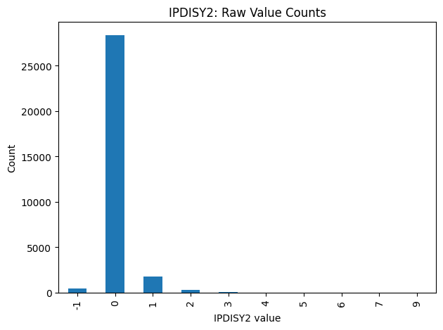

```python
# Purpose: This notebook profiles the analytic cohort, target distribution, and key predictor patterns before modeling. | code block 8.
vc = df[target].value_counts(dropna=False).sort_index()
plt.figure()
vc.plot(kind="bar")
plt.title("IPDISY2: Raw Value Counts")
plt.xlabel("IPDISY2 value")
plt.ylabel("Count")
plt.tight_layout()
plt.savefig(OUT_FIG / "ipdisy2_raw_counts.png", dpi=200)
plt.show()
```

```python
# Purpose: This notebook profiles the analytic cohort, target distribution, and key predictor patterns before modeling. | code block 9.
df_eda = df.copy()

# EDA-only rule: treat negative values as missing for utilization target
df_eda[target] = df_eda[target].where(df_eda[target].isna() | (df_eda[target] >= 0), np.nan)

df_eda[target].describe()
df_eda[target].isna().mean()
```

```
np.float64(0.015383133149206757)
```

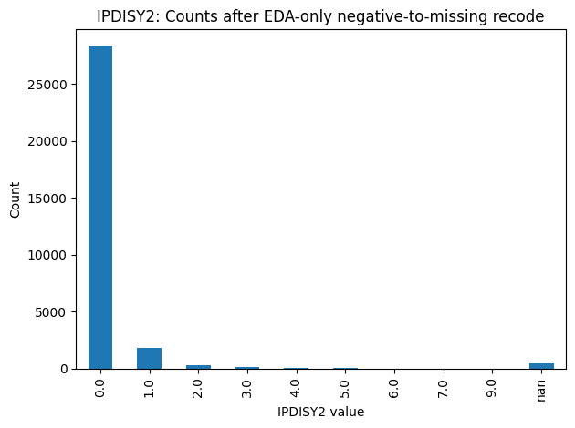

```python
# Purpose: This notebook profiles the analytic cohort, target distribution, and key predictor patterns before modeling. | code block 10.
vc = df_eda[target].value_counts(dropna=False).sort_index()
plt.figure()
vc.plot(kind="bar")
plt.title("IPDISY2: Counts after EDA-only negative-to-missing recode")
plt.xlabel("IPDISY2 value")
plt.ylabel("Count")
plt.tight_layout()
plt.savefig(OUT_FIG / "ipdisy2_counts_after_recode.png", dpi=200)
plt.show()
```

```python
# Purpose: This notebook profiles the analytic cohort, target distribution, and key predictor patterns before modeling. | code block 11.
def band_ipdisy2(x):
    if pd.isna(x):
        return np.nan
    if x == 0:
        return "0"
    if x == 1:
        return "1"
    if x >= 2:
        return "2+"
    return np.nan

df_eda["IPDISY2_BAND"] = df_eda[target].apply(band_ipdisy2)
df_eda["IPDISY2_BAND"].value_counts(dropna=False)
```

```
IPDISY2_BAND
0      28380
1       1818
NaN      479
2+       461
Name: count, dtype: int64
```

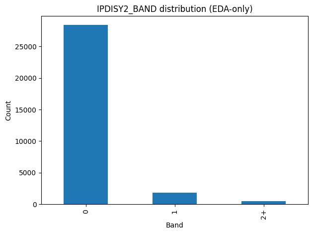

```python
# Purpose: This notebook profiles the analytic cohort, target distribution, and key predictor patterns before modeling. | code block 12.
vc = df_eda["IPDISY2_BAND"].value_counts(dropna=False)
plt.figure()
vc.loc[["0","1","2+"]].plot(kind="bar")  # assumes all exist
plt.title("IPDISY2_BAND distribution (EDA-only)")
plt.xlabel("Band")
plt.ylabel("Count")
plt.tight_layout()
plt.savefig(OUT_FIG / "ipdisy2_band_counts.png", dpi=200)
plt.show()
```

```python
# Purpose: This notebook profiles the analytic cohort, target distribution, and key predictor patterns before modeling. | code block 13.
predictor_cols = [c for c in df_eda.columns if any(
    c.startswith(p) for p in ["AGE", "SEX", "RACE", "HISP", "EDUC", "POVCAT", "INSUR", "ASTH", "DIAB", "ARTH", "HYPER", "CHRON", "ERDISY1", "IPDISY1"]
)]

keep = predictor_cols + [target, "IPDISY2_BAND"]
eda = df_eda[keep].copy()

eda.shape, eda.columns
```

```
((31138, 44),
 Index(['AGE1X', 'AGE2X', 'AGE3X', 'AGE4X', 'AGE5X', 'AGEY1X', 'AGEY2X',
        'AGELSTY1', 'AGELSTY2', 'SEX', 'RACEV1X', 'RACEV2X', 'RACEAX', 'RACEBX',
        'RACEWX', 'RACETHX', 'HISPANX', 'HISPNCAT', 'EDUCYR', 'DIABDXY1_M18',
        'DIABDXY2_M18', 'DIABAGY1', 'DIABAGY2', 'ARTHDXY1', 'ARTHDXY2',
        'ARTHTPY1', 'ARTHTPY2', 'ARTHAGY1', 'ARTHAGY2', 'ASTHDXY1', 'ASTHDXY2',
        'ASTHAGY1', 'ASTHAGY2', 'ASTHEP1', 'ASTHEP3', 'POVCATY1', 'POVCATY2',
        'INSURCY1', 'INSURCY2', 'IPDISY1', 'ASTHEP5', 'AGE_MAX', 'IPDISY2',
        'IPDISY2_BAND'],
       dtype='str'))
```

```python
# Purpose: This notebook profiles the analytic cohort, target distribution, and key predictor patterns before modeling. | code block 14.
missing = (eda.isna().mean().sort_values(ascending=False) * 100).round(2)
missing.head(30)
```

```
ASTHEP5         78.23
IPDISY2          1.54
IPDISY2_BAND     1.54
AGE1X            0.00
AGE5X            0.00
AGEY1X           0.00
AGEY2X           0.00
AGELSTY1         0.00
AGELSTY2         0.00
AGE2X            0.00
AGE3X            0.00
AGE4X            0.00
RACEV2X          0.00
RACEV1X          0.00
SEX              0.00
RACEAX           0.00
HISPANX          0.00
RACEBX           0.00
RACEWX           0.00
RACETHX          0.00
DIABDXY2_M18     0.00
DIABAGY1         0.00
DIABAGY2         0.00
ARTHDXY1         0.00
ARTHDXY2         0.00
HISPNCAT         0.00
EDUCYR           0.00
DIABDXY1_M18     0.00
ARTHAGY1         0.00
ARTHTPY2         0.00
dtype: float64
```

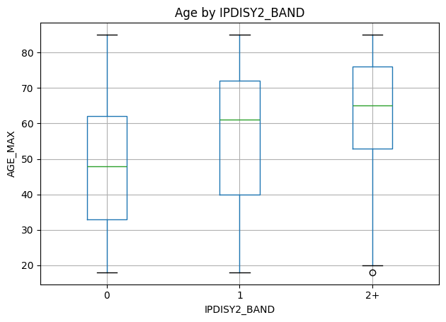

```python
# Purpose: This notebook profiles the analytic cohort, target distribution, and key predictor patterns before modeling. | code block 15.
age_col = "AGE_MAX" if "AGE_MAX" in eda.columns else None

if age_col:
    tmp = eda[[age_col, "IPDISY2_BAND"]].dropna()
    plt.figure()
    tmp.boxplot(column=age_col, by="IPDISY2_BAND")
    plt.title("Age by IPDISY2_BAND")
    plt.suptitle("")
    plt.xlabel("IPDISY2_BAND")
    plt.ylabel(age_col)
    plt.tight_layout()
    plt.savefig(OUT_FIG / "age_by_band.png", dpi=200)
    plt.show()
```

```python
# Purpose: This notebook profiles the analytic cohort, target distribution, and key predictor patterns before modeling. | code block 16.
def crosstab_band(col):
    tab = pd.crosstab(eda[col], eda["IPDISY2_BAND"], normalize="index")
    return tab

for col in [c for c in ["SEX", "INSURCOVY1", "POVCATY1", "EDUCY1"] if c in eda.columns]:
    display(crosstab_band(col))
```

| IPDISY2_BAND SEX | 0 | 1 | 2+ |
| --- | --- | --- | --- |
| 1 | 0.939617 | 0.047335 | 0.013048 |
| 2 | 0.913298 | 0.069903 | 0.016799 |

| IPDISY2_BAND POVCATY1 | 0 | 1 | 2+ |
| --- | --- | --- | --- |
| -1 | 0.932203 | 0.067797 | 0.000000 |
| 1 | 0.893108 | 0.080334 | 0.026558 |
| 2 | 0.896774 | 0.076703 | 0.026523 |
| 3 | 0.906736 | 0.072045 | 0.021219 |
| 4 | 0.932645 | 0.056110 | 0.011245 |
| 5 | 0.942850 | 0.047134 | 0.010016 |

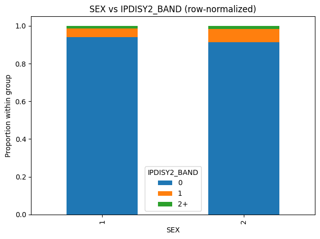

```python
# Purpose: This notebook profiles the analytic cohort, target distribution, and key predictor patterns before modeling. | code block 17.
col = "SEX" if "SEX" in eda.columns else None
if col:
    tab = pd.crosstab(eda[col], eda["IPDISY2_BAND"], normalize="index")[["0","1","2+"]]
    plt.figure()
    tab.plot(kind="bar", stacked=True)
    plt.title(f"{col} vs IPDISY2_BAND (row-normalized)")
    plt.xlabel(col)
    plt.ylabel("Proportion within group")
    plt.tight_layout()
    plt.savefig(OUT_FIG / f"{col.lower()}_vs_band.png", dpi=200)
    plt.show()
```

```python
# Purpose: This notebook profiles the analytic cohort, target distribution, and key predictor patterns before modeling. | code block 18.
chronic_flags = [c for c in eda.columns if any(c.startswith(p) for p in ["ASTH", "DIAB", "ARTH", "HYPER", "CHRON"])]

summary = []
for c in chronic_flags:
    if eda[c].dropna().nunique() <= 10:  # avoid weird continuous
        tab = pd.crosstab(eda[c], eda["IPDISY2_BAND"], normalize="index")
        summary.append((c, tab))

# Show first few
for c, tab in summary[:6]:
    print("\n", c)
    display(tab)
```

```
 DIABDXY1_M18
```

| IPDISY2_BAND DIABDXY1_M18 | 0 | 1 | 2+ |
| --- | --- | --- | --- |
| -8 | 1.000000 | 0.000000 | 0.000000 |
| -7 | 1.000000 | 0.000000 | 0.000000 |
| -1 | 0.932203 | 0.067797 | 0.000000 |
| 1 | 0.840717 | 0.112605 | 0.046677 |
| 2 | 0.937654 | 0.051750 | 0.010596 |

```
 DIABDXY2_M18
```

| IPDISY2_BAND DIABDXY2_M18 | 0 | 1 | 2+ |
| --- | --- | --- | --- |
| -15 | 1.000000 | 0.000000 | 0.000000 |
| -8 | 1.000000 | 0.000000 | 0.000000 |
| -7 | 1.000000 | 0.000000 | 0.000000 |
| -1 | 0.941176 | 0.058824 | 0.000000 |
| 1 | 0.841151 | 0.112464 | 0.046385 |
| 2 | 0.937817 | 0.051651 | 0.010532 |

```
 ARTHDXY1
```

| IPDISY2_BAND ARTHDXY1 | 0 | 1 | 2+ |
| --- | --- | --- | --- |
| -8 | 1.000000 | 0.000000 | 0.000000 |
| -7 | 1.000000 | 0.000000 | 0.000000 |
| -1 | 0.973929 | 0.024209 | 0.001862 |
| 1 | 0.854570 | 0.109278 | 0.036151 |
| 2 | 0.947147 | 0.044226 | 0.008626 |

```
 ARTHDXY2
```

| IPDISY2_BAND ARTHDXY2 | 0 | 1 | 2+ |
| --- | --- | --- | --- |
| -15 | 0.970238 | 0.023810 | 0.005952 |
| -8 | 1.000000 | 0.000000 | 0.000000 |
| -7 | 1.000000 | 0.000000 | 0.000000 |
| -1 | 0.974490 | 0.025510 | 0.000000 |
| 1 | 0.856128 | 0.108474 | 0.035398 |
| 2 | 0.947604 | 0.043810 | 0.008587 |

```
 ARTHTPY1
```

| IPDISY2_BAND ARTHTPY1 | 0 | 1 | 2+ |
| --- | --- | --- | --- |
| -7 | 0.625000 | 0.250000 | 0.125000 |
| -1 | 0.947785 | 0.043748 | 0.008467 |
| 1 | 0.845447 | 0.111947 | 0.042607 |
| 2 | 0.837741 | 0.124375 | 0.037884 |
| 3 | 0.872861 | 0.095049 | 0.032090 |

```
 ARTHTPY2
```

| IPDISY2_BAND ARTHTPY2 | 0 | 1 | 2+ |
| --- | --- | --- | --- |
| -7 | 0.666667 | 0.222222 | 0.111111 |
| -1 | 0.948019 | 0.043490 | 0.008491 |
| 1 | 0.845710 | 0.112211 | 0.042079 |
| 2 | 0.839804 | 0.123120 | 0.037076 |
| 3 | 0.874186 | 0.094435 | 0.031380 |

```python
# Purpose: This notebook profiles the analytic cohort, target distribution, and key predictor patterns before modeling. | code block 19.
cost_cols = [c for c in ["TOTEXPY2", "RXEXPY2"] if c in df_eda.columns]
cost_cols
```

```
['TOTEXPY2', 'RXEXPY2']
```

```python
# Purpose: This notebook profiles the analytic cohort, target distribution, and key predictor patterns before modeling. | code block 20.
for c in cost_cols:
    df_eda[c] = df_eda[c].where(df_eda[c].isna() | (df_eda[c] >= 0), np.nan)

context = df_eda[["IPDISY2_BAND"] + cost_cols].dropna(subset=["IPDISY2_BAND"])
context.describe()
```

|  | TOTEXPY2 | RXEXPY2 |
| --- | --- | --- |
| count | 3.065900e+04 | 3.065900e+04 |
| mean | 7.339484e+03 | 1.810315e+03 |
| std | 2.022185e+04 | 1.118066e+04 |
| min | 0.000000e+00 | 0.000000e+00 |
| 25% | 2.370000e+02 | 0.000000e+00 |
| 50% | 1.631000e+03 | 5.500000e+01 |
| 75% | 6.316500e+03 | 5.640000e+02 |
| max | 1.338276e+06 | 1.287862e+06 |

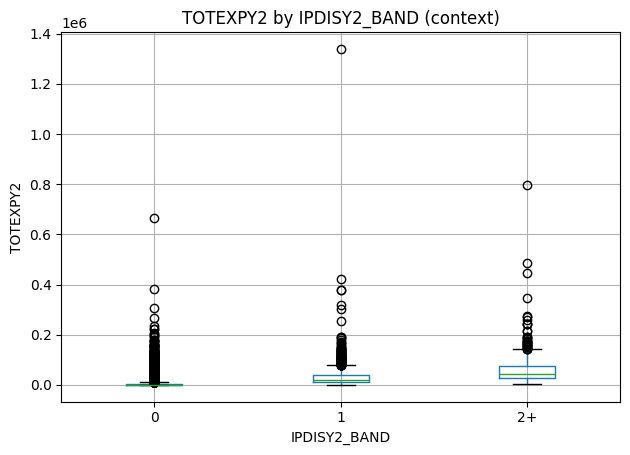

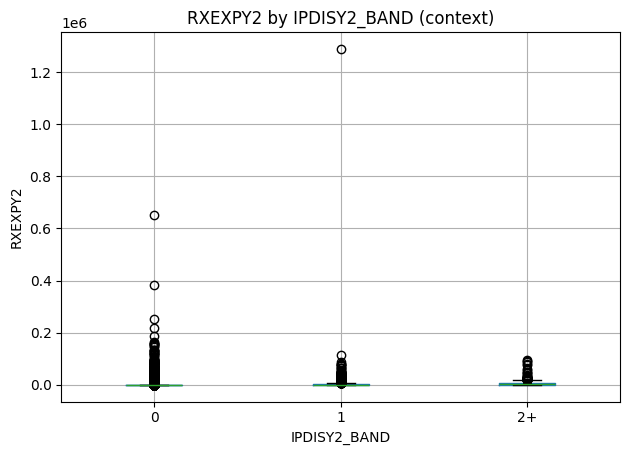

```python
# Purpose: This notebook profiles the analytic cohort, target distribution, and key predictor patterns before modeling. | code block 21.
for c in cost_cols:
    tmp = context[[c, "IPDISY2_BAND"]].dropna()
    plt.figure()
    tmp.boxplot(column=c, by="IPDISY2_BAND")
    plt.title(f"{c} by IPDISY2_BAND (context)")
    plt.suptitle("")
    plt.xlabel("IPDISY2_BAND")
    plt.ylabel(c)
    plt.tight_layout()
    plt.savefig(OUT_FIG / f"{c.lower()}_by_band.png", dpi=200)
    plt.show()
```

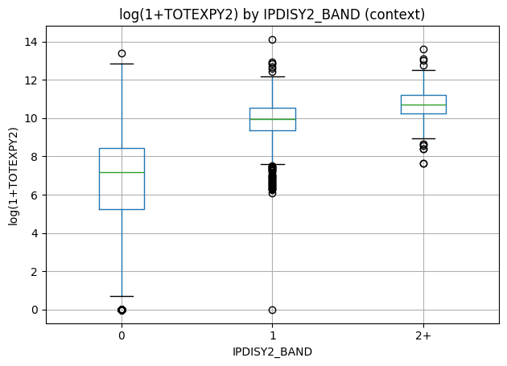

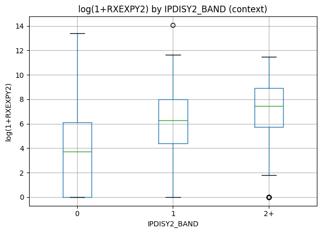

```python
# Purpose: This notebook profiles the analytic cohort, target distribution, and key predictor patterns before modeling. | code block 22.
for c in cost_cols:
    tmp = context[[c, "IPDISY2_BAND"]].dropna()
    tmp[c + "_LOG1P"] = np.log1p(tmp[c])
    plt.figure()
    tmp.boxplot(column=c + "_LOG1P", by="IPDISY2_BAND")
    plt.title(f"log(1+{c}) by IPDISY2_BAND (context)")
    plt.suptitle("")
    plt.xlabel("IPDISY2_BAND")
    plt.ylabel(f"log(1+{c})")
    plt.tight_layout()
    plt.savefig(OUT_FIG / f"{c.lower()}_log1p_by_band.png", dpi=200)
    plt.show()
```

Exploratory Data Analysis (EDA) Summary Cohort Overview

The analytic cohort consists of 31,138 non-cancer adults (AGE ≥ 18) drawn from MEPS Household Component longitudinal panels 23–27 (2018–2023). Cancer cases were excluded using longitudinal summary indicators (CANCERY1, CANCERY2). All observations correspond to valid panel participants, and no event-level files were required at this stage.

Target Variable: Inpatient Utilization (IPDISY2)

The primary outcome explored is inpatient discharges in Year 2 (IPDISY2). Raw values exhibit strong zero inflation, which is expected in population-level utilization data. Negative MEPS codes were treated as missing for EDA visualization only.

To support interpretability and modeling feasibility, IPDISY2 was temporarily grouped into three utilization bands (EDA-only):

0: No inpatient stays

1: One inpatient stay

2+: Two or more inpatient stays

The resulting distribution shows a dominant zero-utilization group with clinically meaningful minority classes, supporting a multiclass framing rather than a binary outcome.

Demographic Patterns

Age demonstrates a clear monotonic relationship with inpatient utilization intensity. Median age increases across utilization bands (0 → 1 → 2+), with the highest utilization group skewing older. Sex-stratified analyses show modest but consistent differences in utilization proportions across bands, suggesting demographic relevance without extreme imbalance.

Chronic Condition Indicators

Overall, chronic condition indicators demonstrate meaningful signal for inpatient utilization risk.

Cost Variables (Contextual Analysis)

Total healthcare expenditures (TOTEXPY2) and prescription drug expenditures (RXEXPY2) were analyzed as contextual outcomes, not modeling targets. Both cost measures are highly right-skewed, with extreme outliers, which is typical for MEPS data.

Log-transformed visualizations (log(1 + x)) show a clear monotonic increase in expenditures across inpatient utilization bands, with the highest costs concentrated among individuals with multiple inpatient stays. These patterns validate the clinical and economic relevance of the utilization outcome.

Missingness and Data Quality

Overall missingness across core demographic, utilization, and condition variables is minimal. A small proportion of missing values in IPDISY2 is attributable to MEPS coding conventions and was handled conservatively during EDA. No observations were dropped based on missingness at this stage.

EDA Conclusions

The EDA supports progression to feature engineering and model development, with no structural or data integrity issues identified.

```python
# Purpose: This notebook profiles the analytic cohort, target distribution, and key predictor patterns before modeling. | code block 23.
```

## Analysis Notebook

`notebooks/3.0_feature_preparation.ipynb`

**Purpose:** Model-ready feature preparation and preprocessing.

## Reviewer Guide

This notebook prepares the model-ready feature matrix, applies cleaning rules, and saves the final dataset used for training and holdout evaluation.

# Feature Preparation (Model-Ready Dataset)

Purpose: Build a leakage-safe, model-ready dataset using Year-1 predictors only.

Steps

1. Load analysis-ready data
2. Define Y_IPDISY2_CLASS target
3. Select leakage-safe features (Y1 only)
4. Handle missingness and reduce redundancy
5. Encode categorical variables
6. Save model-ready parquet

```python
# Purpose: This notebook prepares the model-ready feature matrix, applies cleaning rules, and saves the final dataset used for training and holdout evaluation. | code block 1.
import pandas as pd
import numpy as np
from pathlib import Path

PROJECT_ROOT = Path('..') if Path('..').exists() else Path('.')
DATA_PATH_EVENTS = PROJECT_ROOT / 'data' / 'processed' / 'meps_group6_analysis_ready_events.parquet'
DATA_PATH_BASE   = PROJECT_ROOT / 'data' / 'processed' / 'meps_group6_analysis_ready.parquet'
DATA_PATH = DATA_PATH_EVENTS if DATA_PATH_EVENTS.exists() else DATA_PATH_BASE

OUT_PATH_EVENTS = PROJECT_ROOT / 'data' / 'processed' / 'meps_group6_model_ready_events.parquet'
OUT_PATH_BASE   = PROJECT_ROOT / 'data' / 'processed' / 'meps_group6_model_ready.parquet'
OUT_PATH = OUT_PATH_EVENTS if DATA_PATH == DATA_PATH_EVENTS else OUT_PATH_BASE

df = pd.read_parquet(DATA_PATH)

print('Loaded:', DATA_PATH)
df.shape, df.columns[:20]
```

```
Loaded: ..\data\processed\meps_group6_analysis_ready_events.parquet
```

```
((31138, 72),
 Index(['DUPERSID', 'PANEL', 'AGE1X', 'AGE2X', 'AGE3X', 'AGE4X', 'AGE5X',
        'AGEY1X', 'AGEY2X', 'AGELSTY1', 'AGELSTY2', 'SEX', 'RACEV1X', 'RACEV2X',
        'RACEAX', 'RACEBX', 'RACEWX', 'RACETHX', 'HISPANX', 'HISPNCAT'],
       dtype='object'))
```

```python
# Purpose: This notebook prepares the model-ready feature matrix, applies cleaning rules, and saves the final dataset used for training and holdout evaluation. | code block 2.
df.info(show_counts=True)
df.head(3)
```

```
<class 'pandas.core.frame.DataFrame'>
RangeIndex: 31138 entries, 0 to 31137
Data columns (total 72 columns):
 #   Column                 Non-Null Count  Dtype
---  ------                 --------------  -----
 0   DUPERSID               31138 non-null  int64
 1   PANEL                  31138 non-null  int64
 2   AGE1X                  31138 non-null  int64
 3   AGE2X                  31138 non-null  int64
 4   AGE3X                  31138 non-null  int64
 5   AGE4X                  31138 non-null  int64
 6   AGE5X                  31138 non-null  int64
 7   AGEY1X                 31138 non-null  int64
 8   AGEY2X                 31138 non-null  int64
 9   AGELSTY1               31138 non-null  int64
```

[output cut: 64 more lines]

|  | DUPERSID | PANEL | AGE1X | AGE2X | AGE3X | AGE4X | AGE5X | AGEY1X | AGEY2X | AGELSTY1 | ... | rx_count_y1 | rx_cost_y1 | ip_count_y1 | ip_cost_y1 | er_count_y1 | er_cost_y1 | cond_count_y1 | chronic_cond_count_y1 | injury_any_y1 | icd10_unique_y1 |
| --- | --- | --- | --- | --- | --- | --- | --- | --- | --- | --- | --- | --- | --- | --- | --- | --- | --- | --- | --- | --- | --- |
| 0 | 2320002101 | 23 | 30 | 30 | 31 | 32 | 32 | 31 | 32 | 31 | ... | 0.0 | 0.0 | 0.0 | 0.0 | 0.0 | 0.0 | 0.0 | 0.0 | 0.0 | 0.0 |
| 1 | 2320002102 | 23 | 41 | 41 | 41 | 42 | 42 | 41 | 42 | 41 | ... | 0.0 | 0.0 | 0.0 | 0.0 | 0.0 | 0.0 | 0.0 | 0.0 | 0.0 | 0.0 |
| 2 | 2320005101 | 23 | 70 | 71 | 71 | 72 | 72 | 71 | 72 | 71 | ... | 0.0 | 0.0 | 0.0 | 0.0 | 0.0 | 0.0 | 0.0 | 0.0 | 0.0 | 0.0 |

3 rows × 72 columns

```python
# Purpose: This notebook prepares the model-ready feature matrix, applies cleaning rules, and saves the final dataset used for training and holdout evaluation. | code block 3.
TARGET_RAW = "IPDISY2"

# Treat negative codes as missing for the target
df[TARGET_RAW] = df[TARGET_RAW].where(df[TARGET_RAW].isna() | (df[TARGET_RAW] >= 0), np.nan)

def make_ipdisy2_class(x):
    if pd.isna(x):
        return np.nan
    if x == 0:
        return 0
    if x == 1:
        return 1
    if x >= 2:
        return 2
    return np.nan

df["Y_IPDISY2_CLASS"] = df[TARGET_RAW].apply(make_ipdisy2_class)

df["Y_IPDISY2_CLASS"].value_counts(dropna=False)
```

```
Y_IPDISY2_CLASS
0.0    28380
1.0     1818
NaN      479
2.0      461
Name: count, dtype: int64
```

```python
# Purpose: This notebook prepares the model-ready feature matrix, applies cleaning rules, and saves the final dataset used for training and holdout evaluation. | code block 4.
df_model = df.dropna(subset=["Y_IPDISY2_CLASS"]).copy()
df_model.shape, df.shape
```

```
((30659, 73), (31138, 73))
```

```python
# Purpose: This notebook prepares the model-ready feature matrix, applies cleaning rules, and saves the final dataset used for training and holdout evaluation. | code block 5.
EXCLUDE_COLS_EXACT = {
    'DUPERSID',
    'CANCERY1', 'CANCERY2',
    'IPDISY2',
}

EXCLUDE_PREFIXES = ('TOTEXPY2', 'RXEXPY2', 'ERDISY2', 'IPDISY2')

exclude_cols = set([c for c in df_model.columns if c in EXCLUDE_COLS_EXACT])
exclude_cols |= set([c for c in df_model.columns if c.startswith(EXCLUDE_PREFIXES)])
# Drop any Year-2 fields anywhere in name (leakage)
exclude_cols |= set([c for c in df_model.columns if 'Y2' in c])

sorted(list(exclude_cols))[:30], len(exclude_cols)
```

```
(['AGELSTY2',
  'AGEY2X',
  'ARTHAGY2',
  'ARTHDXY2',
  'ARTHTPY2',
  'ASTHAGY2',
  'ASTHDXY2',
  'CANCERY1',
  'CANCERY2',
  'DIABAGY2',
  'DIABDXY2_M18',
  'DUPERSID',
  'INSURCY2',
  'IPDISY2',
  'POVCATY2',
  'RXEXPY2',
  'TOTEXPY2',
  'Y_IPDISY2_CLASS'],
 18)
```

```python
# Purpose: This notebook prepares the model-ready feature matrix, applies cleaning rules, and saves the final dataset used for training and holdout evaluation. | code block 6.
ALLOWED_PREFIXES = (
    'AGE', 'SEX', 'RACE', 'HISP',
    'EDUC', 'POVCAT', 'INSUR',
    'ASTH', 'DIAB', 'ARTH', 'HYPER', 'CHRON',
    'ERDISY1', 'IPDISY1',
    'TOTEXPY1', 'RXEXPY1', 'OBEXPY1'
)

candidate_features = [
    c for c in df_model.columns
    if any(c.startswith(p) for p in ALLOWED_PREFIXES) or c.endswith('_y1')
]

if 'AGE_MAX' in df_model.columns and 'AGE_MAX' not in candidate_features:
    candidate_features.append('AGE_MAX')

candidate_features = [c for c in candidate_features if c not in exclude_cols]
# remove any leftover Y2 fields just in case
candidate_features = [c for c in candidate_features if 'Y2' not in c]

len(candidate_features), candidate_features[:25]
```

```
(43,
 ['AGE1X',
  'AGE2X',
  'AGE3X',
  'AGE4X',
  'AGE5X',
  'AGEY1X',
  'AGELSTY1',
  'SEX',
  'RACEV1X',
  'RACEV2X',
  'RACEAX',
  'RACEBX',
  'RACEWX',
  'RACETHX',
  'HISPANX',
  'HISPNCAT',
  'EDUCYR',
  'DIABDXY1_M18',
  'DIABAGY1',
  'ARTHDXY1',
  'ARTHTPY1',
  'ARTHAGY1',
  'ASTHDXY1',
  'ASTHAGY1',
  'ASTHEP1'])
```

```python
# Purpose: This notebook prepares the model-ready feature matrix, applies cleaning rules, and saves the final dataset used for training and holdout evaluation. | code block 7.
X = df_model[candidate_features].copy()
y = df_model["Y_IPDISY2_CLASS"].astype(int)

X.shape, y.shape, y.value_counts()
```

```
((30659, 43),
 (30659,),
 Y_IPDISY2_CLASS
 0    28380
 1     1818
 2      461
 Name: count, dtype: int64)
```

```python
# Purpose: This notebook prepares the model-ready feature matrix, applies cleaning rules, and saves the final dataset used for training and holdout evaluation. | code block 8.
# Drop high-missingness features (>50%)
missing_rate = X.isna().mean()
high_missing = missing_rate[missing_rate > 0.5].index.tolist()
print('Dropping high-missing features:', high_missing)
X = X.drop(columns=high_missing)
X.shape
```

```
Dropping high-missing features: ['ASTHEP5']
```

```
(30659, 42)
```

```python
# Purpose: This notebook prepares the model-ready feature matrix, applies cleaning rules, and saves the final dataset used for training and holdout evaluation. | code block 9.
# --- Reduce AGE redundancy: keep only AGE_MAX ---

age_cols_to_drop = [
    c for c in X.columns
    if c.startswith("AGE") and c != "AGE_MAX"
]

age_cols_to_drop
```

```
['AGE1X', 'AGE2X', 'AGE3X', 'AGE4X', 'AGE5X', 'AGEY1X', 'AGELSTY1']
```

```python
# Purpose: This notebook prepares the model-ready feature matrix, applies cleaning rules, and saves the final dataset used for training and holdout evaluation. | code block 10.
X = X.drop(columns=age_cols_to_drop)

X.shape
```

```
(30659, 35)
```

```python
# Purpose: This notebook prepares the model-ready feature matrix, applies cleaning rules, and saves the final dataset used for training and holdout evaluation. | code block 11.
# Identify numeric columns
num_cols = X.select_dtypes(include=[np.number]).columns

# Replace negative values with NaN in numeric columns only
X[num_cols] = X[num_cols].mask(X[num_cols] < 0)

# Sanity check
X.isna().mean().sort_values(ascending=False).head(20)
```

```
ASTHEP3         0.969047
ASTHEP1         0.921720
DIABAGY1        0.881144
ASTHAGY1        0.870315
ARTHAGY1        0.776477
ARTHTPY1        0.762973
ARTHDXY1        0.017841
EDUCYR          0.007339
DIABDXY1_M18    0.002120
ASTHDXY1        0.002120
INSURCY1        0.001924
IPDISY1         0.001924
TOTEXPY1        0.001924
POVCATY1        0.001924
RXEXPY1         0.001924
RACEV2X         0.000000
RACEV1X         0.000000
SEX             0.000000
HISPANX         0.000000
RACETHX         0.000000
dtype: float64
```

```python
# Purpose: This notebook prepares the model-ready feature matrix, applies cleaning rules, and saves the final dataset used for training and holdout evaluation. | code block 12.
X.shape
```

```
(30659, 35)
```

```python
# Purpose: This notebook prepares the model-ready feature matrix, applies cleaning rules, and saves the final dataset used for training and holdout evaluation. | code block 13.
y.value_counts()
```

```
Y_IPDISY2_CLASS
0    28380
1     1818
2      461
Name: count, dtype: int64
```

```python
# Purpose: This notebook prepares the model-ready feature matrix, applies cleaning rules, and saves the final dataset used for training and holdout evaluation. | code block 14.
cat_cols = []
num_cols_final = []

for c in X.columns:
    nunique = X[c].dropna().nunique()
    if X[c].dtype == "object" or nunique <= 12:
        cat_cols.append(c)
    else:
        num_cols_final.append(c)

len(cat_cols), len(num_cols_final)
```

```
(20, 15)
```

```python
# Purpose: This notebook prepares the model-ready feature matrix, applies cleaning rules, and saves the final dataset used for training and holdout evaluation. | code block 15.
X_encoded = pd.get_dummies(
    X,
    columns=cat_cols,
    dummy_na=True,
    drop_first=False
)

X_encoded.shape
```

```
(30659, 131)
```

```python
# Purpose: This notebook prepares the model-ready feature matrix, applies cleaning rules, and saves the final dataset used for training and holdout evaluation. | code block 16.
model_ready = X_encoded.copy()
model_ready["Y_IPDISY2_CLASS"] = y.values

model_ready.to_parquet(OUT_PATH, index=False)

OUT_PATH, model_ready.shape
```

```
(WindowsPath('../data/processed/meps_group6_model_ready_events.parquet'),
 (30659, 132))
```

```python
# Purpose: This notebook prepares the model-ready feature matrix, applies cleaning rules, and saves the final dataset used for training and holdout evaluation. | code block 17.
model_ready["Y_IPDISY2_CLASS"].value_counts()
```

```
Y_IPDISY2_CLASS
0    28380
1     1818
2      461
Name: count, dtype: int64
```

```python
# Purpose: This notebook prepares the model-ready feature matrix, applies cleaning rules, and saves the final dataset used for training and holdout evaluation. | code block 18.
model_ready.isna().mean().sort_values(ascending=False).head(10)
```

```
DIABAGY1       0.881144
ASTHAGY1       0.870315
ARTHAGY1       0.776477
EDUCYR         0.007339
TOTEXPY1       0.001924
RXEXPY1        0.001924
AGE_MAX        0.000000
rx_count_y1    0.000000
rx_cost_y1     0.000000
ip_cost_y1     0.000000
dtype: float64
```

```python
# Purpose: This notebook prepares the model-ready feature matrix, applies cleaning rules, and saves the final dataset used for training and holdout evaluation. | code block 19.
```

```python
# Purpose: This notebook prepares the model-ready feature matrix, applies cleaning rules, and saves the final dataset used for training and holdout evaluation. | code block 20.
```

## Analysis Notebook

`notebooks/4.0_model_creation_and_evaluation.ipynb`

**Purpose:** Baseline model training and holdout evaluation.

## Reviewer Guide